# Predicting Default Payments of Credit Card Clients in Taiwan Ruobing Wang June 8, 2019

## Overview

In the real life, when a customer of a bank fall into financial difficulties, it usually do not happen at once.

For banks, risk management and default detection has always been a crucial part in issuing credit cards.

All in all, defaults on credit card bill payment can result in great financial loss.

In order to reduce or even prevent loss of this kind, banks need to determine appropriate given credit for each specific client based on their information. There are some indicators which we can use to expect the final outcome. Such like late payments.

In this project, we will use the data of credit card clients in Taiwan from April 2005 to September 2005 which contains information on default payments, demographic factors, credit data, history of payment, and bill statements to see:

1. How does the probability of default payment vary by categories of different demographic variables?
2. Which variables are the strongest predictors of default payment?

This is a really really long report. I spend a lot of time on the EDA part and try two different ways to solve problems which you can see in a second. Basically, it will do as the following sequence:

- 1. Visualize the dataset and check the imbalance and missing data.
- 1. Using decision tree as the first time and found we can not simply use the accuracy score. Then I use F1 score.
- 1. Data cleaning and Feature engineering
- 1. Sampling by using upsample, downsample and SMOTE.
- 1. Training and Testing
- 1. Finding the threshold and find the best f1 score
- 1. Using ROC AUC to solve this problem again.

#### Reference

[Kaggle: Credit Card Default](https://www.kaggle.com/uciml/default-of-credit-card-clients-dataset)

Here are all the packages we will use in this project:

```python
import numpy as np
import pandas as pd

import seaborn as sns
import matplotlib.pyplot as plt
%matplotlib inline
```

## Data

The dataset can be found at:

http://archive.ics.uci.edu/ml/datasets/default+of+credit+card+clients#

The credit card issuer has gathered information on 30000 customers. The dataset contains information on 25 variables, including demographic factors, credit data, history of payment, and bill statements of credit card customers from April 2005 to September 2005, as well as information on the outcome: did the customer default or not?

There are 25 variables:

```
ID: ID of each client

LIMIT_BAL: Amount of given credit in NT dollars (includes individual and family/supplementary credit

SEX: Gender (1=male, 2=female)

EDUCATION: (1=graduate school, 2=university, 3=high school, 4=others, 5=unknown, 6=unknown)

MARRIAGE: Marital status (1=married, 2=single, 3=others)

AGE: Age in years

PAY_0: Repayment status in September, 2005 (-1=pay duly, 1=payment delay for one month, 2=payment delay for two months, ... 8=payment delay for eight months, 9=payment delay for nine months and above)
PAY_2: Repayment status in August, 2005 (scale same as above)
PAY_3: Repayment status in July, 2005 (scale same as above)
PAY_4: Repayment status in June, 2005 (scale same as above)
PAY_5: Repayment status in May, 2005 (scale same as above)
PAY_6: Repayment status in April, 2005 (scale same as above)

BILL_AMT1: Amount of bill statement in September, 2005 (NT dollar)
BILL_AMT2: Amount of bill statement in August, 2005 (NT dollar)
BILL_AMT3: Amount of bill statement in July, 2005 (NT dollar)
BILL_AMT4: Amount of bill statement in June, 2005 (NT dollar)
BILL_AMT5: Amount of bill statement in May, 2005 (NT dollar)
BILL_AMT6: Amount of bill statement in April, 2005 (NT dollar)

PAY_AMT1: Amount of previous payment in September, 2005 (NT dollar)
PAY_AMT2: Amount of previous payment in August, 2005 (NT dollar)
PAY_AMT3: Amount of previous payment in July, 2005 (NT dollar)
PAY_AMT4: Amount of previous payment in June, 2005 (NT dollar)
PAY_AMT5: Amount of previous payment in May, 2005 (NT dollar)
PAY_AMT6: Amount of previous payment in April, 2005 (NT dollar)

default.payment.next.month: Default payment (1=yes, 0=no)
```

Let's see the brief overview of the dataset:

```python
df = pd.read_csv('UCI_Credit_Card.csv')
df.sample(5)
```

|  | ID | LIMIT_BAL | SEX | EDUCATION | MARRIAGE | AGE | PAY_0 | PAY_2 | PAY_3 | PAY_4 | ... | BILL_AMT4 | BILL_AMT5 | BILL_AMT6 | PAY_AMT1 | PAY_AMT2 | PAY_AMT3 | PAY_AMT4 | PAY_AMT5 | PAY_AMT6 | default.payment.next.month |
| --- | --- | --- | --- | --- | --- | --- | --- | --- | --- | --- | --- | --- | --- | --- | --- | --- | --- | --- | --- | --- | --- |
| 14689 | 14690 | 70000.0 | 2 | 2 | 2 | 26 | 0 | 0 | 0 | 0 | ... | 22587.0 | 24361.0 | 25424.0 | 3000.0 | 3005.0 | 3000.0 | 3000.0 | 1500.0 | 1008.0 | 0 |
| 16471 | 16472 | 200000.0 | 2 | 1 | 1 | 47 | 0 | 0 | 0 | 0 | ... | 89550.0 | 98565.0 | 54370.0 | 4000.0 | 3455.0 | 5000.0 | 10000.0 | 2500.0 | 2231.0 | 0 |
| 4168 | 4169 | 90000.0 | 1 | 2 | 2 | 33 | 0 | 0 | 0 | 0 | ... | 61710.0 | 63020.0 | 64274.0 | 3000.0 | 3000.0 | 2300.0 | 2300.0 | 2300.0 | 2379.0 | 1 |
| 5824 | 5825 | 50000.0 | 2 | 3 | 1 | 70 | 2 | 2 | 0 | 0 | ... | 30363.0 | 30444.0 | 30482.0 | 0.0 | 2504.0 | 1200.0 | 1500.0 | 1100.0 | 1301.0 | 0 |
| 718 | 719 | 150000.0 | 2 | 1 | 1 | 35 | 1 | -2 | -2 | -2 | ... | 0.0 | 0.0 | 0.0 | 0.0 | 0.0 | 0.0 | 0.0 | 0.0 | 0.0 | 0 |

5 rows × 25 columns

```python
df.info()
```

```
<class 'pandas.core.frame.DataFrame'>
RangeIndex: 30000 entries, 0 to 29999
Data columns (total 25 columns):
ID                            30000 non-null int64
LIMIT_BAL                     30000 non-null float64
SEX                           30000 non-null int64
EDUCATION                     30000 non-null int64
MARRIAGE                      30000 non-null int64
AGE                           30000 non-null int64
PAY_0                         30000 non-null int64
PAY_2                         30000 non-null int64
PAY_3                         30000 non-null int64
PAY_4                         30000 non-null int64
PAY_5                         30000 non-null int64
PAY_6                         30000 non-null int64
BILL_AMT1                     30000 non-null float64
BILL_AMT2                     30000 non-null float64
BILL_AMT3                     30000 non-null float64
BILL_AMT4                     30000 non-null float64
BILL_AMT5                     30000 non-null float64
BILL_AMT6                     30000 non-null float64
PAY_AMT1                      30000 non-null float64
PAY_AMT2                      30000 non-null float64
PAY_AMT3                      30000 non-null float64
PAY_AMT4                      30000 non-null float64
PAY_AMT5                      30000 non-null float64
PAY_AMT6                      30000 non-null float64
default.payment.next.month    30000 non-null int64
dtypes: float64(13), int64(12)
memory usage: 5.7 MB
```

```python
df.shape
```

```
(30000, 25)
```

## Exploratory Data Analysis

From the overview, we can see that there are 30000 customers in this bank and each customer we use 25 predictors to evaluate the default or not.

At the very beginning, let's check if there are missing or anomalous data.

### Categorical Variables:

```python
df[['SEX', 'EDUCATION', 'MARRIAGE']].describe()
```

|  | SEX | EDUCATION | MARRIAGE |
| --- | --- | --- | --- |
| count | 30000.000000 | 30000.000000 | 30000.000000 |
| mean | 1.603733 | 1.853133 | 1.551867 |
| std | 0.489129 | 0.790349 | 0.521970 |
| min | 1.000000 | 0.000000 | 0.000000 |
| 25% | 1.000000 | 1.000000 | 1.000000 |
| 50% | 2.000000 | 2.000000 | 2.000000 |
| 75% | 2.000000 | 2.000000 | 2.000000 |
| max | 2.000000 | 6.000000 | 3.000000 |

```python
total = df.isnull().sum().sort_values(ascending = False)
percent = (df.isnull().sum()/df.isnull().count()*100).sort_values(ascending = False)
pd.concat([total, percent], axis=1, keys=['Total', 'Percent']).transpose()
```

|  | default.payment.next.month | PAY_6 | LIMIT_BAL | SEX | EDUCATION | MARRIAGE | AGE | PAY_0 | PAY_2 | PAY_3 | ... | BILL_AMT3 | BILL_AMT4 | BILL_AMT5 | BILL_AMT6 | PAY_AMT1 | PAY_AMT2 | PAY_AMT3 | PAY_AMT4 | PAY_AMT5 | ID |
| --- | --- | --- | --- | --- | --- | --- | --- | --- | --- | --- | --- | --- | --- | --- | --- | --- | --- | --- | --- | --- | --- |
| Total | 0.0 | 0.0 | 0.0 | 0.0 | 0.0 | 0.0 | 0.0 | 0.0 | 0.0 | 0.0 | ... | 0.0 | 0.0 | 0.0 | 0.0 | 0.0 | 0.0 | 0.0 | 0.0 | 0.0 | 0.0 |
| Percent | 0.0 | 0.0 | 0.0 | 0.0 | 0.0 | 0.0 | 0.0 | 0.0 | 0.0 | 0.0 | ... | 0.0 | 0.0 | 0.0 | 0.0 | 0.0 | 0.0 | 0.0 | 0.0 | 0.0 | 0.0 |

2 rows × 25 columns

From the form, since percentage is 0, then, no missing data. But, we can see that here are some interesting problems:

```python
ls = df['SEX'].unique().tolist()
ls.sort()
print('Categorical value of sex: ')
print(ls)
```

```
Categorical value of sex:
[1, 2]
```

```python
ls = df['EDUCATION'].unique().tolist()
ls.sort()
print('Categorical value of education: ')
print(ls)
```

```
Categorical value of education:
[0, 1, 2, 3, 4, 5, 6]
```

```python
ls = df['MARRIAGE'].unique().tolist()
ls.sort()
print('Categorical value of marriage: ')
print(ls)
```

```
Categorical value of marriage:
[0, 1, 2, 3]
```

Surprisingly,

1. Education has category 5 and 6 that are unlabelled(unknown), moreover the category 0 is undocumented(does not appear in the description of dataset).
2. MARRIAGE has a label 0 that is undocumented

### Payment delay description:

```python
df[['PAY_0', 'PAY_2', 'PAY_3', 'PAY_4', 'PAY_5', 'PAY_6']].describe()
```

|  | PAY_0 | PAY_2 | PAY_3 | PAY_4 | PAY_5 | PAY_6 |
| --- | --- | --- | --- | --- | --- | --- |
| count | 30000.000000 | 30000.000000 | 30000.000000 | 30000.000000 | 30000.000000 | 30000.000000 |
| mean | -0.016700 | -0.133767 | -0.166200 | -0.220667 | -0.266200 | -0.291100 |
| std | 1.123802 | 1.197186 | 1.196868 | 1.169139 | 1.133187 | 1.149988 |
| min | -2.000000 | -2.000000 | -2.000000 | -2.000000 | -2.000000 | -2.000000 |
| 25% | -1.000000 | -1.000000 | -1.000000 | -1.000000 | -1.000000 | -1.000000 |
| 50% | 0.000000 | 0.000000 | 0.000000 | 0.000000 | 0.000000 | 0.000000 |
| 75% | 0.000000 | 0.000000 | 0.000000 | 0.000000 | 0.000000 | 0.000000 |
| max | 8.000000 | 8.000000 | 8.000000 | 8.000000 | 8.000000 | 8.000000 |

Similarly, we can see that the min is -2 which is undocumented. 0 should be labeled 'pay duly' and every negative value should be seen as a 0. And other numbers like 1,2,3... are the months of delay.

### Bill Statement description

```python
df[['BILL_AMT1', 'BILL_AMT2', 'BILL_AMT3', 'BILL_AMT4', 'BILL_AMT5', 'BILL_AMT6']].describe()
```

|  | BILL_AMT1 | BILL_AMT2 | BILL_AMT3 | BILL_AMT4 | BILL_AMT5 | BILL_AMT6 |
| --- | --- | --- | --- | --- | --- | --- |
| count | 30000.000000 | 30000.000000 | 3.000000e+04 | 30000.000000 | 30000.000000 | 30000.000000 |
| mean | 51223.330900 | 49179.075167 | 4.701315e+04 | 43262.948967 | 40311.400967 | 38871.760400 |
| std | 73635.860576 | 71173.768783 | 6.934939e+04 | 64332.856134 | 60797.155770 | 59554.107537 |
| min | -165580.000000 | -69777.000000 | -1.572640e+05 | -170000.000000 | -81334.000000 | -339603.000000 |
| 25% | 3558.750000 | 2984.750000 | 2.666250e+03 | 2326.750000 | 1763.000000 | 1256.000000 |
| 50% | 22381.500000 | 21200.000000 | 2.008850e+04 | 19052.000000 | 18104.500000 | 17071.000000 |
| 75% | 67091.000000 | 64006.250000 | 6.016475e+04 | 54506.000000 | 50190.500000 | 49198.250000 |
| max | 964511.000000 | 983931.000000 | 1.664089e+06 | 891586.000000 | 927171.000000 | 961664.000000 |

Nothing important, but we should be careful the negative value of the negative values, since we do not know whether it can be interpreted as credit.

### Previous Payment Description

```python
df[['PAY_AMT1', 'PAY_AMT2', 'PAY_AMT3', 'PAY_AMT4', 'PAY_AMT5', 'PAY_AMT6']].describe()
```

|  | PAY_AMT1 | PAY_AMT2 | PAY_AMT3 | PAY_AMT4 | PAY_AMT5 | PAY_AMT6 |
| --- | --- | --- | --- | --- | --- | --- |
| count | 30000.000000 | 3.000000e+04 | 30000.00000 | 30000.000000 | 30000.000000 | 30000.000000 |
| mean | 5663.580500 | 5.921163e+03 | 5225.68150 | 4826.076867 | 4799.387633 | 5215.502567 |
| std | 16563.280354 | 2.304087e+04 | 17606.96147 | 15666.159744 | 15278.305679 | 17777.465775 |
| min | 0.000000 | 0.000000e+00 | 0.00000 | 0.000000 | 0.000000 | 0.000000 |
| 25% | 1000.000000 | 8.330000e+02 | 390.00000 | 296.000000 | 252.500000 | 117.750000 |
| 50% | 2100.000000 | 2.009000e+03 | 1800.00000 | 1500.000000 | 1500.000000 | 1500.000000 |
| 75% | 5006.000000 | 5.000000e+03 | 4505.00000 | 4013.250000 | 4031.500000 | 4000.000000 |
| max | 873552.000000 | 1.684259e+06 | 896040.00000 | 621000.000000 | 426529.000000 | 528666.000000 |

Nothing special, it is good.

### Amount of given credit in NT dollars

```python
df.LIMIT_BAL.describe()
```

```
count      30000.000000
mean      167484.322667
std       129747.661567
min        10000.000000
25%        50000.000000
50%       140000.000000
75%       240000.000000
max      1000000.000000
Name: LIMIT_BAL, dtype: float64
```

Good, except the range is very broad.

There are two columns very annoying, and I change the name here:

```python
df = df.rename(columns={'default.payment.next.month': 'def_pay',
                        'PAY_0': 'PAY_1'})
df.head()
```

|  | ID | LIMIT_BAL | SEX | EDUCATION | MARRIAGE | AGE | PAY_1 | PAY_2 | PAY_3 | PAY_4 | ... | BILL_AMT4 | BILL_AMT5 | BILL_AMT6 | PAY_AMT1 | PAY_AMT2 | PAY_AMT3 | PAY_AMT4 | PAY_AMT5 | PAY_AMT6 | def_pay |
| --- | --- | --- | --- | --- | --- | --- | --- | --- | --- | --- | --- | --- | --- | --- | --- | --- | --- | --- | --- | --- | --- |
| 0 | 1 | 20000.0 | 2 | 2 | 1 | 24 | 2 | 2 | -1 | -1 | ... | 0.0 | 0.0 | 0.0 | 0.0 | 689.0 | 0.0 | 0.0 | 0.0 | 0.0 | 1 |
| 1 | 2 | 120000.0 | 2 | 2 | 2 | 26 | -1 | 2 | 0 | 0 | ... | 3272.0 | 3455.0 | 3261.0 | 0.0 | 1000.0 | 1000.0 | 1000.0 | 0.0 | 2000.0 | 1 |
| 2 | 3 | 90000.0 | 2 | 2 | 2 | 34 | 0 | 0 | 0 | 0 | ... | 14331.0 | 14948.0 | 15549.0 | 1518.0 | 1500.0 | 1000.0 | 1000.0 | 1000.0 | 5000.0 | 0 |
| 3 | 4 | 50000.0 | 2 | 2 | 1 | 37 | 0 | 0 | 0 | 0 | ... | 28314.0 | 28959.0 | 29547.0 | 2000.0 | 2019.0 | 1200.0 | 1100.0 | 1069.0 | 1000.0 | 0 |
| 4 | 5 | 50000.0 | 1 | 2 | 1 | 57 | -1 | 0 | -1 | 0 | ... | 20940.0 | 19146.0 | 19131.0 | 2000.0 | 36681.0 | 10000.0 | 9000.0 | 689.0 | 679.0 | 0 |

5 rows × 25 columns

Then let's see the default probability over all of the agents:

```python
df.def_pay.sum() / len(df.def_pay)
```

```
0.2212
```

From these charts, we can get:

There are 30,000 distinct credit card clients.

The average value for the amount of credit card limit is 167,484. The standard deviation is unusually large, max value being 1M.

Education level is mostly graduate school and university.

Most of the clients are either marrined or single (less frequent the other status).

As the value 0 for default payment means 'not default' and value 1 means 'default', the mean of 0.221 means that there are 22.1% of credit card contracts that will default next month.

## Models

Since it is a classification problem, we really have lots of choices to use, like the following algorithms:

- Logistic regression
- Decision tree
- Random forest
- Support Vector Classifications
- Stocastic Gradient Descend
- Nearest Neighbours Classifiers
- Gaussian Process Classification
- Other ensemble
- Neural Network Models
- XGBoost

For here, I want to try the models and to see whether there are some significant improvements.

Based on the knowledge I have so far, I will start with Decision tree.

### Decision Tree

Decision tree is a easy way to use and can handle both numerical and categorical variables. However, we need to care about the overfitting. To avoid this, we always use random forest.

There are a few parameters to be settle for the classifier, such as the function to determine the quality of a split, or how deep the tree has to be. We will first test it with a random choice of those parameters and then see a better process.

```python
from sklearn.tree import DecisionTreeClassifier
from sklearn.metrics import accuracy_score, make_scorer
from sklearn.model_selection import train_test_split
```

```python
# create the target variable
y = df['def_pay'].copy()
y.sample(5)
```

```
11024    0
8833     0
17662    0
6566     1
20127    1
Name: def_pay, dtype: int64
```

```python
features = ['LIMIT_BAL', 'SEX', 'EDUCATION', 'MARRIAGE', 'AGE', 'PAY_1', 'PAY_2',
       'PAY_3', 'PAY_4', 'PAY_5', 'PAY_6', 'BILL_AMT1', 'BILL_AMT2',
       'BILL_AMT3', 'BILL_AMT4', 'BILL_AMT5', 'BILL_AMT6', 'PAY_AMT1',
       'PAY_AMT2', 'PAY_AMT3', 'PAY_AMT4', 'PAY_AMT5', 'PAY_AMT6']
X = df[features].copy()
X.columns
```

```
Index(['LIMIT_BAL', 'SEX', 'EDUCATION', 'MARRIAGE', 'AGE', 'PAY_1', 'PAY_2',
       'PAY_3', 'PAY_4', 'PAY_5', 'PAY_6', 'BILL_AMT1', 'BILL_AMT2',
       'BILL_AMT3', 'BILL_AMT4', 'BILL_AMT5', 'BILL_AMT6', 'PAY_AMT1',
       'PAY_AMT2', 'PAY_AMT3', 'PAY_AMT4', 'PAY_AMT5', 'PAY_AMT6'],
      dtype='object')
```

Split the df into train and test, it is important these two do not communicate during the training. Set train on 80% and test on the remain 20%

```python
X_train, X_test, y_train, y_test = train_test_split(X, y, test_size=0.20, random_state=42)
```

```python
#check that the target is not far off
print(df.def_pay.describe())
print("---------------------------")
print(y_train.describe())
print("---------------------------")
print(y_test.describe())
```

```
count    30000.000000
mean         0.221200
std          0.415062
min          0.000000
25%          0.000000
50%          0.000000
75%          0.000000
max          1.000000
Name: def_pay, dtype: float64
---------------------------
count    24000.000000
mean         0.221792
std          0.415460
min          0.000000
25%          0.000000
50%          0.000000
75%          0.000000
max          1.000000
Name: def_pay, dtype: float64
---------------------------
count    6000.000000
mean        0.218833
std         0.413490
min         0.000000
25%         0.000000
50%         0.000000
75%         0.000000
max         1.000000
Name: def_pay, dtype: float64
```

```python
#create the classifier
classifier = DecisionTreeClassifier(max_depth=10, random_state=14)
# training the classifier
classifier.fit(X_train, y_train)
# do our predictions on the test
predictions = classifier.predict(X_test)
# see how good we did on the test
accuracy_score(y_true = y_test, y_pred = predictions)
```

```
0.812
```

Ok, not bad. 81% based on the random choice but once we change the number of depth and state. It will mess everything up. To avoid that. I use GridSearchCV for helping me to find the ideal combination of parameters.

Before that, I want to overview the three parameters:

- `criterion` for here, I use gini which measures how often a randomly chosen element would be incorrectly identified or we can also use entropy which measures the information contained by each attribute
- `max depth` is the maximum amount of steps the tree should do
- `max leaf nodes` maximum number of nodes
- `min sample split` a limit to stop further splitting, useful to avoid overfitting

```python
from sklearn.model_selection import GridSearchCV
```

```python
# define the parameters grid
param_grid = {'max_depth': np.arange(3, 10),
             'criterion' : ['gini','entropy'],
             'max_leaf_nodes': [5,10,20,100],
             'min_samples_split': [2, 5, 10, 20]}

# create the grid
grid_tree = GridSearchCV(DecisionTreeClassifier(), param_grid, cv = 5, scoring= 'accuracy')
# the cv option will be clear in a few cells

#training
grid_tree.fit(X_train, y_train)
#let's see the best estimator
print(grid_tree.best_estimator_)
#with its score
print(np.abs(grid_tree.best_score_))
```

```
DecisionTreeClassifier(class_weight=None, criterion='gini', max_depth=3,
            max_features=None, max_leaf_nodes=20,
            min_impurity_decrease=0.0, min_impurity_split=None,
            min_samples_leaf=1, min_samples_split=20,
            min_weight_fraction_leaf=0.0, presort=False, random_state=None,
            splitter='best')
0.8212916666666666
```

Now, it becomes better. And then we need to cross validate to see whether we are overfitting the model. I use the tool of Kfold.

```python
from sklearn.model_selection import KFold
import seaborn as sns
```

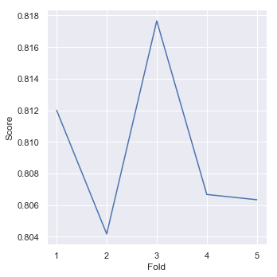

```python
kf = KFold(n_splits=5,random_state=42,shuffle=True)

fold = []
scr = []

for i,(train_index, test_index) in enumerate(kf.split(df)):
    training = df.iloc[train_index,:]
    valid = df.iloc[test_index,:]
    feats = training[features] #defined above
    label = training['def_pay']
    valid_feats = valid[features]
    valid_label = valid['def_pay']
    classifier.fit(feats,label) #it is the last one we run, the best one
    pred = classifier.predict(valid_feats)
    score = accuracy_score(y_true = valid_label, y_pred = pred)
    fold.append(i+1)
    scr.append(score)

#create a small df with the scores
performance = pd.DataFrame({'Score':scr,'Fold':fold})
# let's see what we have with seaborn
sns.set()
sns.relplot(x="Fold", y="Score",kind="line",
            data=performance);
#g = ggplot(performance,aes(x='Fold',y='Score')) + geom_point() + geom_line()
#print(g)
```

Which we can see depending on how split the df into train and test, we get the precision between 0.804 to 0.817.

Next, we can see our features' important ranking for this model:

```python
def get_feature_importance(clsf, ftrs):
    imp = clsf.feature_importances_.tolist()
    feat = ftrs
    result = pd.DataFrame({'feat':feat,'score':imp})
    result = result.sort_values(by=['score'],ascending=False)
    return result

get_feature_importance(classifier, features)
```

|  | feat | score |
| --- | --- | --- |
| 5 | PAY_1 | 0.470918 |
| 6 | PAY_2 | 0.096348 |
| 19 | PAY_AMT3 | 0.054232 |
| 11 | BILL_AMT1 | 0.042192 |
| 4 | AGE | 0.038666 |
| 0 | LIMIT_BAL | 0.031848 |
| 17 | PAY_AMT1 | 0.023829 |
| 7 | PAY_3 | 0.023708 |
| 16 | BILL_AMT6 | 0.023287 |
| 20 | PAY_AMT4 | 0.021213 |
| 21 | PAY_AMT5 | 0.020922 |
| 22 | PAY_AMT6 | 0.019816 |
| 13 | BILL_AMT3 | 0.017819 |
| 10 | PAY_6 | 0.017260 |
| 18 | PAY_AMT2 | 0.016302 |
| 14 | BILL_AMT4 | 0.015922 |
| 12 | BILL_AMT2 | 0.014999 |
| 15 | BILL_AMT5 | 0.013226 |
| 9 | PAY_5 | 0.012128 |
| 8 | PAY_4 | 0.010199 |
| 2 | EDUCATION | 0.008188 |
| 1 | SEX | 0.005743 |
| 3 | MARRIAGE | 0.001233 |

The PAY_1 is the most important. And it is very important that we should tempt to see what happens if we only train on that one.

```python
X = df[['PAY_1']].copy()
X_train, X_test, y_train, y_test = train_test_split(X, y, test_size=0.20, random_state=42)
classifier.fit(X_train, y_train) #same classifier as before
predictions = classifier.predict(X_test)
accuracy_score(y_true = y_test, y_pred = predictions)
```

```
0.8193333333333334
```

```python
from sklearn import tree
import graphviz
dot_data = tree.export_graphviz(classifier, out_file=None)
graph = graphviz.Source(dot_data)
graph
```

[figure not shown]

The good news is decision is very easy to visualize. However, for here, we cannot simply use accuracy score since in our dataset is influenced by the number of clients default. We need to choose f1- score here.

```python
# import the tool
from sklearn.metrics import f1_score
#recreate the model and evaluate it
X = df[features].copy()
X_train, X_test, y_train, y_test = train_test_split(X, y, test_size=0.20, random_state=42)
classifier.fit(X_train, y_train) #same classifier as before
predictions = classifier.predict(X_test)
f1_score(y_true = y_test, y_pred = predictions)
```

```
0.44975609756097557
```

```python
# True Positive (TP): we predict a label of 1 (positive), and the true label is 1.
TP = np.sum(np.logical_and(predictions == 1, y_test == 1))

# True Negative (TN): we predict a label of 0 (negative), and the true label is 0.
TN = np.sum(np.logical_and(predictions == 0, y_test == 0))

# False Positive (FP): we predict a label of 1 (positive), but the true label is 0.
FP = np.sum(np.logical_and(predictions == 1, y_test == 0))

# False Negative (FN): we predict a label of 0 (negative), but the true label is 1.
FN = np.sum(np.logical_and(predictions == 0, y_test == 1))

print('TP: {}, FP: {}, TN: {}, FN: {}'.format(TP,FP,TN,FN))
```

```
TP: 461, FP: 276, TN: 4411, FN: 852
```

Which is very bad. And let's choose the parameter as same as we pick in the accuracy:

```python
param_grid = {'max_depth': np.arange(3, 10),
             'criterion' : ['gini','entropy'],
             'max_leaf_nodes': [5,10,20,100],
             'min_samples_split': [2, 5, 10, 20]}
grid_tree = GridSearchCV(DecisionTreeClassifier(), param_grid, cv = 5, scoring= 'f1')
grid_tree.fit(X_train, y_train)
best = grid_tree.best_estimator_
print(grid_tree.best_estimator_)
print(np.abs(grid_tree.best_score_))
classifier = best
classifier.fit(X_train, y_train)
predictions = classifier.predict(X_test)
print("-------------")
print(f1_score(y_true = y_test, y_pred = predictions))
print(get_feature_importance(classifier, features))
print("-------------")
TP = np.sum(np.logical_and(predictions == 1, y_test == 1))
TN = np.sum(np.logical_and(predictions == 0, y_test == 0))
FP = np.sum(np.logical_and(predictions == 1, y_test == 0))
FN = np.sum(np.logical_and(predictions == 0, y_test == 1))
print('TP: {}, FP: {}, TN: {}, FN: {}'.format(TP,FP,TN,FN))
```

```
DecisionTreeClassifier(class_weight=None, criterion='gini', max_depth=4,
            max_features=None, max_leaf_nodes=20,
            min_impurity_decrease=0.0, min_impurity_split=None,
            min_samples_leaf=1, min_samples_split=2,
            min_weight_fraction_leaf=0.0, presort=False, random_state=None,
            splitter='best')
0.4808469166137819
-------------
0.4735565259582727
         feat     score
5       PAY_1  0.700515
6       PAY_2  0.139945
19   PAY_AMT3  0.053490
9       PAY_5  0.023149
11  BILL_AMT1  0.018404
7       PAY_3  0.016853
0   LIMIT_BAL  0.014510
2   EDUCATION  0.009847
10      PAY_6  0.008586
8       PAY_4  0.007819
4         AGE  0.004113
18   PAY_AMT2  0.002768
3    MARRIAGE  0.000000
1         SEX  0.000000
12  BILL_AMT2  0.000000
13  BILL_AMT3  0.000000
14  BILL_AMT4  0.000000
15  BILL_AMT5  0.000000
16  BILL_AMT6  0.000000
17   PAY_AMT1  0.000000
20   PAY_AMT4  0.000000
21   PAY_AMT5  0.000000
22   PAY_AMT6  0.000000
-------------
TP: 488, FP: 260, TN: 4427, FN: 825
```

Which is better, but still bad for general usage.

```python
param_grid = {'max_depth': np.arange(3, 10),
             'criterion' : ['gini','entropy'],
             'max_leaf_nodes': [5,10,20,100],
             'min_samples_split': [2, 5, 10, 20],
             'class_weight' : ['balanced']}
grid_tree = GridSearchCV(DecisionTreeClassifier(), param_grid, cv = 5, scoring= 'f1')
grid_tree.fit(X_train, y_train)
best = grid_tree.best_estimator_
print(grid_tree.best_estimator_)
print(np.abs(grid_tree.best_score_))
classifier = best
classifier.fit(X_train, y_train)
predictions = classifier.predict(X_test)
print("-------------")
print(f1_score(y_true = y_test, y_pred = predictions))
print(get_feature_importance(classifier, features))
print("-------------")
TP = np.sum(np.logical_and(predictions == 1, y_test == 1))
TN = np.sum(np.logical_and(predictions == 0, y_test == 0))
FP = np.sum(np.logical_and(predictions == 1, y_test == 0))
FN = np.sum(np.logical_and(predictions == 0, y_test == 1))
print('TP: {}, FP: {}, TN: {}, FN: {}'.format(TP,FP,TN,FN))
```

```
DecisionTreeClassifier(class_weight='balanced', criterion='entropy',
            max_depth=3, max_features=None, max_leaf_nodes=20,
            min_impurity_decrease=0.0, min_impurity_split=None,
            min_samples_leaf=1, min_samples_split=2,
            min_weight_fraction_leaf=0.0, presort=False, random_state=None,
            splitter='best')
0.527531438172145
-------------
0.5203784570596798
         feat     score
5       PAY_1  0.782776
18   PAY_AMT2  0.069381
8       PAY_4  0.049357
6       PAY_2  0.039653
0   LIMIT_BAL  0.021069
20   PAY_AMT4  0.011959
19   PAY_AMT3  0.011690
7       PAY_3  0.006434
2   EDUCATION  0.004715
11  BILL_AMT1  0.002967
10      PAY_6  0.000000
1         SEX  0.000000
12  BILL_AMT2  0.000000
13  BILL_AMT3  0.000000
14  BILL_AMT4  0.000000
15  BILL_AMT5  0.000000
16  BILL_AMT6  0.000000
17   PAY_AMT1  0.000000
9       PAY_5  0.000000
4         AGE  0.000000
3    MARRIAGE  0.000000
21   PAY_AMT5  0.000000
22   PAY_AMT6  0.000000
-------------
TP: 715, FP: 720, TN: 3967, FN: 598
```

I guess this happens since I do no clean data well or the dataset is unbalance. I will try again in the following part:

## EDA (Again)

### Categorical variables:

Focusing on the SEX, MARRIAGE, EDUCATION, to see whether there are sparse classes which can overfit models.

```python
df.SEX.value_counts()
```

```
2    18112
1    11888
Name: SEX, dtype: int64
```

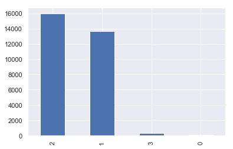

```python
df['MARRIAGE'].value_counts().plot(kind = 'bar')
```

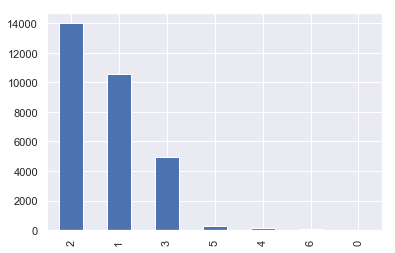

```python
df.EDUCATION.value_counts().plot(kind = 'bar')
```

These graphs show we need to process some classes.

### Numerical variables

Creating a function to use some histograms to have a feel of the distribution, checking if they make sense, the presence of outliers etc

```python
def draw_histograms(df, variables, n_rows, n_cols, n_bins):
    fig=plt.figure()
    for i, var_name in enumerate(variables):
        ax=fig.add_subplot(n_rows,n_cols,i+1)
        df[var_name].hist(bins=n_bins,ax=ax)
        ax.set_title(var_name)
    fig.tight_layout()  # Improves appearance a bit.
    plt.show()
```

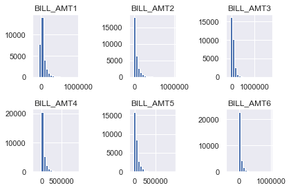

```python
bills = df[['BILL_AMT1','BILL_AMT2', 'BILL_AMT3', 'BILL_AMT4', 'BILL_AMT5', 'BILL_AMT6']]
draw_histograms(bills, bills.columns, 2, 3, 20)
```

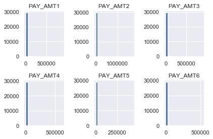

```python
pay = df[['PAY_AMT1','PAY_AMT2', 'PAY_AMT3', 'PAY_AMT4', 'PAY_AMT5', 'PAY_AMT6']]
draw_histograms(pay, pay.columns, 2, 3, 20)
```

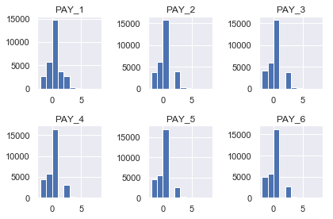

```python
late = df[['PAY_1','PAY_2', 'PAY_3', 'PAY_4', 'PAY_5', 'PAY_6']]
draw_histograms(late, late.columns, 2, 3, 10)

#this is probably more of a category
```

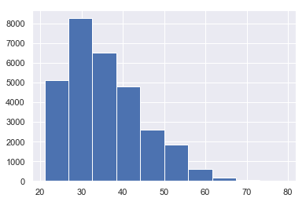

```python
df.AGE.hist()
```

#### Amount of credit limit:

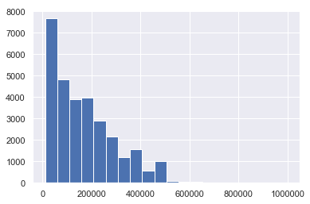

```python
df.LIMIT_BAL.hist(bins = 20)
```

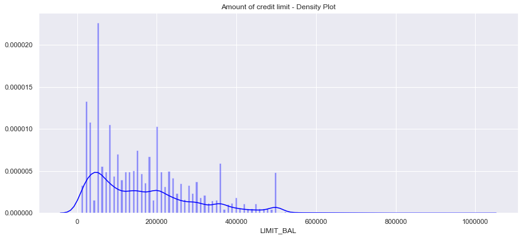

```python
plt.figure(figsize = (14,6))
plt.title('Amount of credit limit - Density Plot')
sns.set_color_codes("pastel")
sns.distplot(df['LIMIT_BAL'],kde=True,bins=200, color="blue")
plt.show()
```

Largest group of amount of credit limit is apparently for amount of 50K.

```python
df['LIMIT_BAL'].value_counts().shape
```

```
(81,)
```

So, there are 81 distinct values for amount of credit limit.

```python
df['LIMIT_BAL'].value_counts().head(5)
```

```
50000.0     3365
20000.0     1976
30000.0     1610
80000.0     1567
200000.0    1528
Name: LIMIT_BAL, dtype: int64
```

So, we can see that the largest number of credit cards are with limit of 50,000 (3365), followed by 20,000 (1976) and 30,000 (1610).

#### Amount of credit limit grouped by default payment next month

Let's visualize the density plot for amount of credit limit (LIMIT_BAL), grouped by default payment next month.

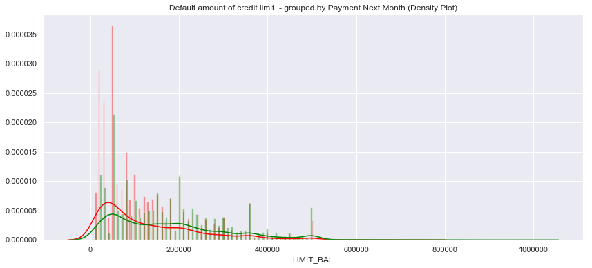

```python
class_0 = df.loc[df['def_pay'] == 0]["LIMIT_BAL"]
class_1 = df.loc[df['def_pay'] == 1]["LIMIT_BAL"]
plt.figure(figsize = (14,6))
plt.title('Default amount of credit limit  - grouped by Payment Next Month (Density Plot)')
sns.set_color_codes("pastel")
sns.distplot(class_1,kde=True,bins=200, color="red")
sns.distplot(class_0,kde=True,bins=200, color="green")
plt.show()
```

Most of defaults are for credit limits 0-100,000 (and density for this interval is larger for defaults than for non-defaults). Larger defaults number are for the amounts of 50,000, 20,000 and 30,000.

#### Credit limit vs. sex

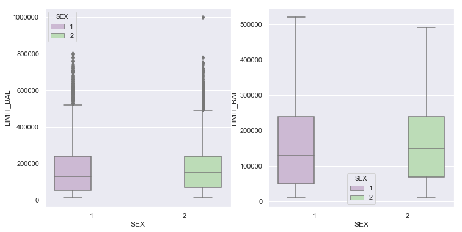

```python
fig, (ax1, ax2) = plt.subplots(ncols=2, figsize=(12,6))
s = sns.boxplot(ax = ax1, x="SEX", y="LIMIT_BAL", hue="SEX",data=df, palette="PRGn",showfliers=True)
s = sns.boxplot(ax = ax2, x="SEX", y="LIMIT_BAL", hue="SEX",data=df, palette="PRGn",showfliers=False)
plt.show();
```

The limit credit amount is quite balanced between sexes. The males have a slightly smaller Q2 and larger Q3 and Q4 and a lower mean. The female have a larger outlier max value (1M NT dollars).

## Data Processing

As seen previously, some categories are mislabeled or undocumented. Before proceeding, it is time to fix it.

- The 0 in MARRIAGE can be safely categorized as 'Other' (thus 3).
- The 0 (undocumented), 5 and 6 (label unknown) in EDUCATION can also be put in a 'Other' cathegory (thus 4)

Thus is a good occasion to learn how to use the .loc function

```python
fil = (df.EDUCATION == 5) | (df.EDUCATION == 6) | (df.EDUCATION == 0)
df.loc[fil, 'EDUCATION'] = 4
df.EDUCATION.value_counts()
```

```
2    14030
1    10585
3     4917
4      468
Name: EDUCATION, dtype: int64
```

```python
df.loc[df.MARRIAGE == 0, 'MARRIAGE'] = 3
df.MARRIAGE.value_counts()
```

```
2    15964
1    13659
3      377
Name: MARRIAGE, dtype: int64
```

For the label other, I guess:

- In Education, it can be education lower than the high school level.
- In Marriage, it can be divorced.

Also, for the pay_n, as we mentioned early, similarly:

I change all negative number to 0 which means pay duly.

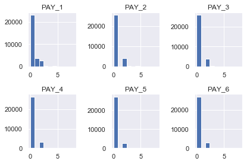

```python
fil = (df.PAY_1 == -2) | (df.PAY_1 == -1) | (df.PAY_1 == 0)
df.loc[fil, 'PAY_1'] = 0
fil = (df.PAY_2 == -2) | (df.PAY_2 == -1) | (df.PAY_2 == 0)
df.loc[fil, 'PAY_2'] = 0
fil = (df.PAY_3 == -2) | (df.PAY_3 == -1) | (df.PAY_3 == 0)
df.loc[fil, 'PAY_3'] = 0
fil = (df.PAY_4 == -2) | (df.PAY_4 == -1) | (df.PAY_4 == 0)
df.loc[fil, 'PAY_4'] = 0
fil = (df.PAY_5 == -2) | (df.PAY_5 == -1) | (df.PAY_5 == 0)
df.loc[fil, 'PAY_5'] = 0
fil = (df.PAY_6 == -2) | (df.PAY_6 == -1) | (df.PAY_6 == 0)
df.loc[fil, 'PAY_6'] = 0
late = df[['PAY_1','PAY_2', 'PAY_3', 'PAY_4', 'PAY_5', 'PAY_6']]
draw_histograms(late, late.columns, 2, 3, 10)
```

There are no negative numbers for PAY_n.

As I mentioned earlier, the range of some clients for the payments are pretty large. I need to investigate whether these are outliers. For example the PAY_AMT1 that are anomalous.

```python
df[df.PAY_AMT1 > 300000][['LIMIT_BAL', 'PAY_1', 'PAY_2', 'BILL_AMT2',
                          'PAY_AMT1', 'BILL_AMT1', 'def_pay']]
```

|  | LIMIT_BAL | PAY_1 | PAY_2 | BILL_AMT2 | PAY_AMT1 | BILL_AMT1 | def_pay |
| --- | --- | --- | --- | --- | --- | --- | --- |
| 2687 | 500000.0 | 0 | 0 | 367979.0 | 368199.0 | 71921.0 | 0 |
| 5687 | 480000.0 | 0 | 0 | 400000.0 | 302000.0 | 106660.0 | 0 |
| 8500 | 400000.0 | 0 | 0 | 405016.0 | 405016.0 | 6500.0 | 0 |
| 12330 | 300000.0 | 1 | 0 | 324392.0 | 505000.0 | -165580.0 | 0 |
| 25431 | 170000.0 | 0 | 0 | 167941.0 | 304815.0 | 30860.0 | 0 |
| 28003 | 510000.0 | 0 | 0 | 481382.0 | 493358.0 | 71121.0 | 0 |
| 28716 | 340000.0 | 0 | 0 | 176743.0 | 873552.0 | 139808.0 | 0 |
| 29820 | 400000.0 | 1 | 0 | 394858.0 | 423903.0 | 396343.0 | 0 |
| 29867 | 340000.0 | 0 | 0 | 331641.0 | 300039.0 | 44855.0 | 0 |
| 29963 | 610000.0 | 0 | 0 | 322228.0 | 323014.0 | 348392.0 | 0 |

And then, after check others similarly. It reveals that they are not outliers but just a client with a lot of money.

After I deal with the wired data. Let's see how relevant each feature is which means it can be used to create new features.

#### Sex and Default

```python
gender = df.groupby(['SEX', 'def_pay']).size().unstack(1)
gender
```

| def_pay SEX | 0 | 1 |
| --- | --- | --- |
| 1 | 9015 | 2873 |
| 2 | 14349 | 3763 |

```python
pd.crosstab(df.SEX, df.def_pay)
gender['perc'] = (gender[1]/(gender[0] + gender[1]))
gender
```

| def_pay SEX | 0 | 1 | perc |
| --- | --- | --- | --- |
| 1 | 9015 | 2873 | 0.241672 |
| 2 | 14349 | 3763 | 0.207763 |

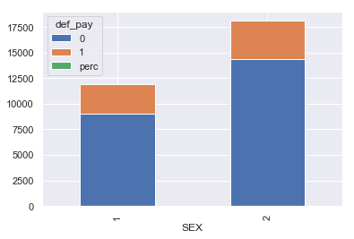

```python
gender.plot(kind='bar', stacked = True)
```

#### Education and Default

And then, let's see how education influence the default rate. For doing that, I create a function to calculate the percentage. It will do the same thing as what we did in Sex and Default but just different method.

```python
def corr_2_cols(Col1, Col2):
    res = df.groupby([Col1, Col2]).size().unstack()
    res['perc'] = (res[res.columns[1]]/(res[res.columns[0]] + res[res.columns[1]]))
    return res
```

```python
corr_2_cols('EDUCATION', 'def_pay')
```

| def_pay EDUCATION | 0 | 1 | perc |
| --- | --- | --- | --- |
| 1 | 8549 | 2036 | 0.192348 |
| 2 | 10700 | 3330 | 0.237349 |
| 3 | 3680 | 1237 | 0.251576 |
| 4 | 435 | 33 | 0.070513 |

So, except "others(4)", the lower the probability of default the higher is the education which make sense since people realize how the result will be if you default.

#### Marriage and Default

```python
corr_2_cols('MARRIAGE', 'def_pay')
```

| def_pay MARRIAGE | 0 | 1 | perc |
| --- | --- | --- | --- |
| 1 | 10453 | 3206 | 0.234717 |
| 2 | 12623 | 3341 | 0.209283 |
| 3 | 288 | 89 | 0.236074 |

For the married people, they have more probability to default as well as other(divorce maybe?)

All in all, these three categories are all important for our result we want to predict.

For my curious, I want to see the relationship between payments and bills:

```python
df[['PAY_AMT6', 'BILL_AMT6', 'PAY_AMT5',
     'BILL_AMT5', 'PAY_AMT4', 'BILL_AMT4', 'PAY_AMT3', 'BILL_AMT3',
     'PAY_AMT2', 'BILL_AMT2',
     'PAY_AMT1', 'BILL_AMT1',
     'LIMIT_BAL', 'def_pay']].sample(10)
```

|  | PAY_AMT6 | BILL_AMT6 | PAY_AMT5 | BILL_AMT5 | PAY_AMT4 | BILL_AMT4 | PAY_AMT3 | BILL_AMT3 | PAY_AMT2 | BILL_AMT2 | PAY_AMT1 | BILL_AMT1 | LIMIT_BAL | def_pay |
| --- | --- | --- | --- | --- | --- | --- | --- | --- | --- | --- | --- | --- | --- | --- |
| 24316 | 5500.0 | 151786.0 | 0.0 | 154113.0 | 10774.0 | 145550.0 | 5500.0 | 143695.0 | 6500.0 | 139216.0 | 4800.0 | 136460.0 | 170000.0 | 0 |
| 4632 | 0.0 | 0.0 | 0.0 | 0.0 | 0.0 | 0.0 | 0.0 | 0.0 | 0.0 | 15525.0 | 1525.0 | 14451.0 | 30000.0 | 0 |
| 26287 | 0.0 | 9592.0 | 0.0 | 9908.0 | 0.0 | 16164.0 | 3418.0 | 13442.0 | 2000.0 | 11952.0 | 2000.0 | 15704.0 | 230000.0 | 0 |
| 8959 | 0.0 | 0.0 | 0.0 | 0.0 | 0.0 | 0.0 | 0.0 | 0.0 | 0.0 | 0.0 | 0.0 | 0.0 | 180000.0 | 0 |
| 13011 | 1500.0 | 39749.0 | 0.0 | 40551.0 | 3200.0 | 37967.0 | 1500.0 | 37086.0 | 2000.0 | 35686.0 | 1600.0 | 34949.0 | 110000.0 | 0 |
| 11663 | 1200.0 | 30847.0 | 2800.0 | 28685.0 | 0.0 | 29289.0 | 1200.0 | 28858.0 | 1200.0 | 28422.0 | 1800.0 | 27358.0 | 50000.0 | 0 |
| 20244 | 13164.0 | 49146.0 | 49146.0 | 23325.0 | 23325.0 | 27782.0 | 27782.0 | 26476.0 | 26476.0 | 31175.0 | 31175.0 | 22443.0 | 300000.0 | 0 |
| 20010 | 3679.0 | 125004.0 | 4881.0 | 143879.0 | 3500.0 | 178416.0 | 7193.0 | 193598.0 | 0.0 | 214479.0 | 17580.0 | 201223.0 | 210000.0 | 1 |
| 25003 | 860.0 | 0.0 | 0.0 | 0.0 | 0.0 | 0.0 | 0.0 | 0.0 | 0.0 | 303.0 | 303.0 | 1090.0 | 360000.0 | 0 |
| 13996 | 1000.0 | 35540.0 | 1000.0 | 64699.0 | 1800.0 | 66897.0 | 2500.0 | 74530.0 | 2962.0 | 81084.0 | 3600.0 | 82922.0 | 340000.0 | 0 |

Just see people who default:

```python
df[df.def_pay == 1][['BILL_AMT2',
     'PAY_AMT1', 'BILL_AMT1', 'PAY_1',
     'LIMIT_BAL']].sample(15)
```

|  | BILL_AMT2 | PAY_AMT1 | BILL_AMT1 | PAY_1 | LIMIT_BAL |
| --- | --- | --- | --- | --- | --- |
| 7070 | 31201.0 | 3600.0 | 28054.0 | 0 | 80000.0 |
| 21601 | 7022.0 | 0.0 | 7285.0 | 2 | 50000.0 |
| 11639 | 18418.0 | 900.0 | 18103.0 | 1 | 30000.0 |
| 6204 | 12906.0 | 1117.0 | 5433.0 | 0 | 50000.0 |
| 4857 | 44646.0 | 0.0 | 45652.0 | 1 | 50000.0 |
| 11299 | 137133.0 | 5700.0 | 137614.0 | 0 | 260000.0 |
| 14912 | 8223.0 | 15450.0 | -4.0 | 0 | 330000.0 |
| 14553 | 555086.0 | 20200.0 | 610723.0 | 0 | 450000.0 |
| 9762 | 5206.0 | 7380.0 | 13416.0 | 0 | 90000.0 |
| 26829 | 26989.0 | 2000.0 | 25411.0 | 0 | 50000.0 |
| 28349 | 176867.0 | 9000.0 | 172360.0 | 2 | 180000.0 |
| 8877 | 5609.0 | 1090.0 | 4743.0 | 1 | 30000.0 |
| 24431 | 55164.0 | 4000.0 | 120766.0 | 0 | 70000.0 |
| 20738 | 25209.0 | 0.0 | 25907.0 | 1 | 30000.0 |
| 5457 | 106423.0 | 0.0 | 110946.0 | 3 | 100000.0 |

It seems like the following relationship:

- I have a BILL of X, I pay Y
- The month after I have to pay X-Y + X', being X' my new expenses, I pay Y'
- The month after I have to pay X+X' - Y - Y' + X'' , I pay Y''

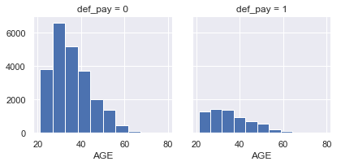

```python
g = sns.FacetGrid(df, col = 'def_pay')
g.map(plt.hist, 'AGE')
```

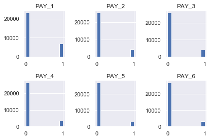

```python
df.loc[df.PAY_1 > 0, 'PAY_1'] = 1
df.loc[df.PAY_2 > 0, 'PAY_2'] = 1
df.loc[df.PAY_3 > 0, 'PAY_3'] = 1
df.loc[df.PAY_4 > 0, 'PAY_4'] = 1
df.loc[df.PAY_5 > 0, 'PAY_5'] = 1
df.loc[df.PAY_6 > 0, 'PAY_6'] = 1
late = df[['PAY_1','PAY_2', 'PAY_3', 'PAY_4', 'PAY_5', 'PAY_6']]
draw_histograms(late, late.columns, 2, 3, 10)
```

For comfortable in the future, I transform the variables to binary variable(late/not late)

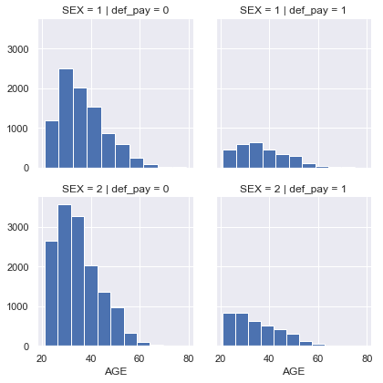

```python
g = sns.FacetGrid(df, col = 'def_pay', row = 'SEX')
g.map(plt.hist, 'AGE')
```

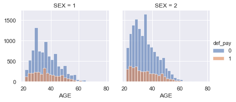

```python
g = sns.FacetGrid(df, col='SEX', hue='def_pay')
g.map(plt.hist, 'AGE', alpha=0.6, bins=25) #alpha is for opacity
g.add_legend()
```

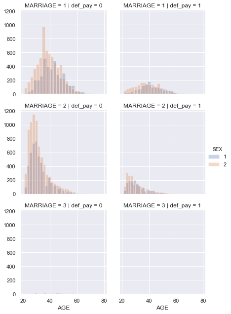

```python
g = sns.FacetGrid(df, col='def_pay', row= "MARRIAGE", hue='SEX')
g.map(plt.hist, 'AGE', alpha=0.3, bins=25)
g.add_legend()
```

So, these graphs telling me combine age with other categories will give me more descriptive feature.

### Feature Engineering

#### Features' Correlation

For the numeric values, let's represent the features correlation.

Let's check the correlation of Amount of bill statement in April - September 2005.

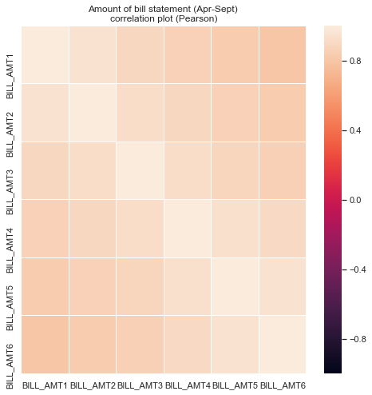

```python
var = ['BILL_AMT1','BILL_AMT2','BILL_AMT3','BILL_AMT4','BILL_AMT5','BILL_AMT6']

plt.figure(figsize = (8,8))
plt.title('Amount of bill statement (Apr-Sept) \ncorrelation plot (Pearson)')
corr = df[var].corr()
sns.heatmap(corr,xticklabels=corr.columns,yticklabels=corr.columns,linewidths=.1,vmin=-1, vmax=1)
plt.show()
```

Correlation is decreasing with distance between months. Lowest correlations are between Sept-April.

Let's check the correlation of Amount of previous payment in April - September 2005.

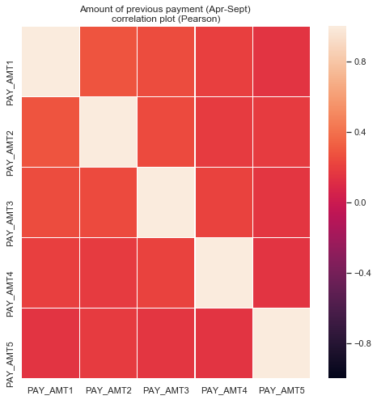

```python
var = ['PAY_AMT1', 'PAY_AMT2', 'PAY_AMT3', 'PAY_AMT4', 'PAY_AMT5']

plt.figure(figsize = (8,8))
plt.title('Amount of previous payment (Apr-Sept) \ncorrelation plot (Pearson)')
corr = df[var].corr()
sns.heatmap(corr,xticklabels=corr.columns,yticklabels=corr.columns,linewidths=.1,vmin=-1, vmax=1)
plt.show()
```

There are barely no correlations between amounts of previous payments for April-Sept 2005.

Let's check the correlation between Repayment status in April - September 2005.

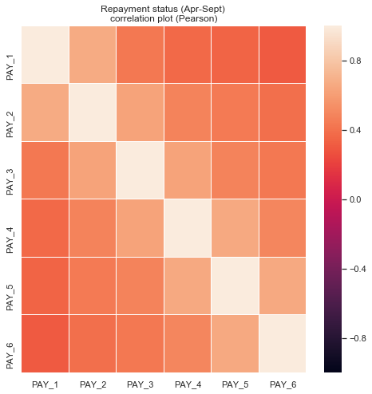

```python
var = ['PAY_1','PAY_2', 'PAY_3', 'PAY_4', 'PAY_5', 'PAY_6']

plt.figure(figsize = (8,8))
plt.title('Repayment status (Apr-Sept) \ncorrelation plot (Pearson)')
corr = df[var].corr()
sns.heatmap(corr,xticklabels=corr.columns,yticklabels=corr.columns,linewidths=.1,vmin=-1, vmax=1)
plt.show()
```

Correlation is decreasing with distance between months. Lowest correlations are between Sept-April.

#### Marriage and Sex

According to our analysis, men are most likely to default and also that married people are most likely to default. So, why not combine them together? Since they are easy labeled then the number will influence the probability which will be easy for use to process.

```python
df['SE_MA'] = df.SEX * df.MARRIAGE
corr_2_cols('SE_MA', 'def_pay')
```

| def_pay SE_MA | 0 | 1 | perc |
| --- | --- | --- | --- |
| 1 | 3844 | 1346 | 0.259345 |
| 2 | 11677 | 3345 | 0.222673 |
| 3 | 103 | 42 | 0.289655 |
| 4 | 7555 | 1856 | 0.197216 |
| 6 | 185 | 47 | 0.202586 |

In this way, we can know that:

as the result, 3 has the most percentage.

But I think I can do more:

```python
df['SE_MA_2'] = 0
df.loc[((df.SEX == 1) & (df.MARRIAGE == 1)) , 'SE_MA_2'] = 1 #married man
df.loc[((df.SEX == 1) & (df.MARRIAGE == 2)) , 'SE_MA_2'] = 2 #single man
df.loc[((df.SEX == 1) & (df.MARRIAGE == 3)) , 'SE_MA_2'] = 3 #divorced man
df.loc[((df.SEX == 2) & (df.MARRIAGE == 1)) , 'SE_MA_2'] = 4 #married woman
df.loc[((df.SEX == 2) & (df.MARRIAGE == 2)) , 'SE_MA_2'] = 5 #single woman
df.loc[((df.SEX == 2) & (df.MARRIAGE == 3)) , 'SE_MA_2'] = 6 #divorced woman
corr_2_cols('SE_MA_2', 'def_pay')
```

| def_pay SE_MA_2 | 0 | 1 | perc |
| --- | --- | --- | --- |
| 1 | 3844 | 1346 | 0.259345 |
| 2 | 5068 | 1485 | 0.226614 |
| 3 | 103 | 42 | 0.289655 |
| 4 | 6609 | 1860 | 0.219625 |
| 5 | 7555 | 1856 | 0.197216 |
| 6 | 185 | 47 | 0.202586 |

This chart will be more meaningful since it can tell us that married men have a higher probability of defaulting, single men have nothing special with respect to the all population and single women have a lower probability of defaulting. Among the divorced, men have more troubles.

```python
del df['SE_MA']
df = df.rename(columns={'SE_MA_2': 'SE_MA'})
```

#### AgeBin

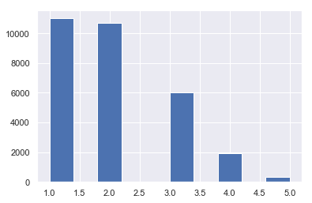

```python
df['AgeBin'] = pd.cut(df['AGE'], 6, labels = [1,2,3,4,5,6])
#because 1 2 3 ecc are "categories" so far and we need numbers
df['AgeBin'] = pd.to_numeric(df['AgeBin'])
df.loc[(df['AgeBin'] == 6) , 'AgeBin'] = 5
df.AgeBin.hist()
```

```python
corr_2_cols('AgeBin', 'def_pay')
```

| def_pay AgeBin | 0 | 1 | perc |
| --- | --- | --- | --- |
| 1 | 8542 | 2471 | 0.224371 |
| 2 | 8524 | 2189 | 0.204331 |
| 3 | 4606 | 1399 | 0.232973 |
| 4 | 1449 | 481 | 0.249223 |
| 5 | 243 | 96 | 0.283186 |

```python
corr_2_cols('AgeBin', 'SEX')
```

| SEX AgeBin | 1 | 2 | perc |
| --- | --- | --- | --- |
| 1 | 3842 | 7171 | 0.651140 |
| 2 | 4363 | 6350 | 0.592738 |
| 3 | 2587 | 3418 | 0.569192 |
| 4 | 917 | 1013 | 0.524870 |
| 5 | 179 | 160 | 0.471976 |

The default probability goes down before 30's and then goes higher and higher. Also, the percentage of men is growing with the age category. So, combine the two like what we did before:

```python
df['SE_AG'] = 0
df.loc[((df.SEX == 1) & (df.AgeBin == 1)) , 'SE_AG'] = 1 #man in 20's
df.loc[((df.SEX == 1) & (df.AgeBin == 2)) , 'SE_AG'] = 2 #man in 30's
df.loc[((df.SEX == 1) & (df.AgeBin == 3)) , 'SE_AG'] = 3 #man in 40's
df.loc[((df.SEX == 1) & (df.AgeBin == 4)) , 'SE_AG'] = 4 #man in 50's
df.loc[((df.SEX == 1) & (df.AgeBin == 5)) , 'SE_AG'] = 5 #man in 60's and above
df.loc[((df.SEX == 2) & (df.AgeBin == 1)) , 'SE_AG'] = 6 #woman in 20's
df.loc[((df.SEX == 2) & (df.AgeBin == 2)) , 'SE_AG'] = 7 #woman in 30's
df.loc[((df.SEX == 2) & (df.AgeBin == 3)) , 'SE_AG'] = 8 #woman in 40's
df.loc[((df.SEX == 2) & (df.AgeBin == 4)) , 'SE_AG'] = 9 #woman in 50's
df.loc[((df.SEX == 2) & (df.AgeBin == 5)) , 'SE_AG'] = 10 #woman in 60's and above
corr_2_cols('SE_AG', 'def_pay')
```

| def_pay SE_AG | 0 | 1 | perc |
| --- | --- | --- | --- |
| 1 | 2929 | 913 | 0.237637 |
| 2 | 3350 | 1013 | 0.232180 |
| 3 | 1939 | 648 | 0.250483 |
| 4 | 666 | 251 | 0.273719 |
| 5 | 131 | 48 | 0.268156 |
| 6 | 5613 | 1558 | 0.217264 |
| 7 | 5174 | 1176 | 0.185197 |
| 8 | 2667 | 751 | 0.219719 |
| 9 | 783 | 230 | 0.227048 |
| 10 | 112 | 48 | 0.300000 |

#### Sex, Education, Age and Marriage

Start by showing the boxplots with age distribution grouped by marriage status and sex.

```python
def boxplot_variation(feature1, feature2, feature3, width=16):
    fig, ax1 = plt.subplots(ncols=1, figsize=(width,6))
    s = sns.boxplot(ax = ax1, x=feature1, y=feature2, hue=feature3,
                data=df, palette="PRGn",showfliers=False)
    s.set_xticklabels(s.get_xticklabels(),rotation=90)
    plt.show();
```

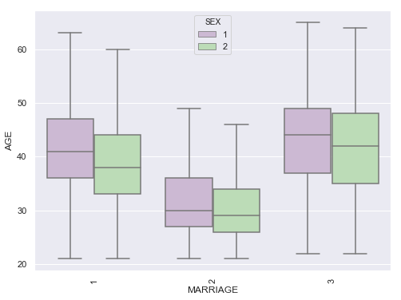

```python
boxplot_variation('MARRIAGE','AGE', 'SEX',8)
```

Married males have mean age above married women. Unmarried males have mean value for age above unmarried women as well but closer. Q2 and Q3 values for married man are above corresponding values for married women.

Let's show the boxplots with age distribution grouped by education and marriage.

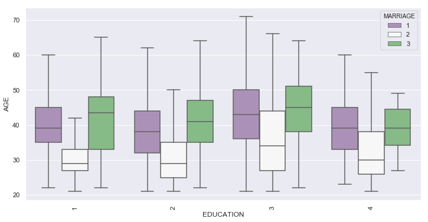

```python
boxplot_variation('EDUCATION','AGE', 'MARRIAGE',12)
```

#### Age, sex and credit amount limit

Let's show the boxplots with credit amount limit distribution grouped by age and sex.

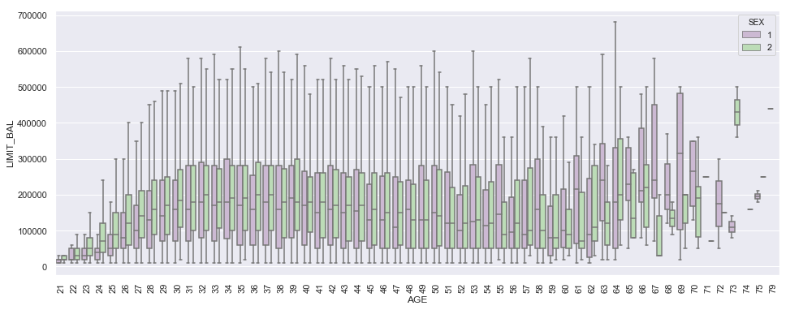

```python
boxplot_variation('AGE','LIMIT_BAL', 'SEX',16)
```

Mean, Q3 and Q4 values are increasing for both male and female with age until aroung 35 years and then they are oscilating and get to a maximum of Q4 for males at age 64.

`Mean values are generally smaller for males than for females`, with few exceptions, for example at age 39, 48, until approximately 60, where mean values for males are generally larger than for females.

#### Info of Clients:

For being a client, it must at a given month. Thus, if PAY, BILL_AMT and PAY_AMT are 0, then we are not talking about a client. Here are how I process it.

```python
df['Client_6'] = 1
df['Client_5'] = 1
df['Client_4'] = 1
df['Client_3'] = 1
df['Client_2'] = 1
df['Client_1'] = 1
df.loc[((df.PAY_6 == 0) & (df.BILL_AMT6 == 0) & (df.PAY_AMT6 == 0)) , 'Client_6'] = 0
df.loc[((df.PAY_5 == 0) & (df.BILL_AMT5 == 0) & (df.PAY_AMT5 == 0)) , 'Client_5'] = 0
df.loc[((df.PAY_4 == 0) & (df.BILL_AMT4 == 0) & (df.PAY_AMT4 == 0)) , 'Client_4'] = 0
df.loc[((df.PAY_3 == 0) & (df.BILL_AMT3 == 0) & (df.PAY_AMT3 == 0)) , 'Client_3'] = 0
df.loc[((df.PAY_2 == 0) & (df.BILL_AMT2 == 0) & (df.PAY_AMT2 == 0)) , 'Client_2'] = 0
df.loc[((df.PAY_1 == 0) & (df.BILL_AMT1 == 0) & (df.PAY_AMT1 == 0)) , 'Client_1'] = 0
pd.Series([df[df.Client_6 == 1].def_pay.count(),
          df[df.Client_5 == 1].def_pay.count(),
          df[df.Client_4 == 1].def_pay.count(),
          df[df.Client_3 == 1].def_pay.count(),
          df[df.Client_2 == 1].def_pay.count(),
          df[df.Client_1 == 1].def_pay.count()], [6,5,4,3,2,1])
```

```
6    26700
5    27247
4    27572
3    27810
2    28183
1    29477
dtype: int64
```

And then, I need some information of the clients' expense, for here, I use average. But the denominator is LIMIT_BAL because we can know in what extend a client care about the expense.

```python
df['Avg_exp_5'] = ((df['BILL_AMT5'] - (df['BILL_AMT6'] - df['PAY_AMT5']))) / df['LIMIT_BAL']
df['Avg_exp_4'] = (((df['BILL_AMT5'] - (df['BILL_AMT6'] - df['PAY_AMT5'])) +
                 (df['BILL_AMT4'] - (df['BILL_AMT5'] - df['PAY_AMT4']))) / 2) / df['LIMIT_BAL']
df['Avg_exp_3'] = (((df['BILL_AMT5'] - (df['BILL_AMT6'] - df['PAY_AMT5'])) +
                 (df['BILL_AMT4'] - (df['BILL_AMT5'] - df['PAY_AMT4'])) +
                 (df['BILL_AMT3'] - (df['BILL_AMT4'] - df['PAY_AMT3']))) / 3) / df['LIMIT_BAL']
df['Avg_exp_2'] = (((df['BILL_AMT5'] - (df['BILL_AMT6'] - df['PAY_AMT5'])) +
                 (df['BILL_AMT4'] - (df['BILL_AMT5'] - df['PAY_AMT4'])) +
                 (df['BILL_AMT3'] - (df['BILL_AMT4'] - df['PAY_AMT3'])) +
                 (df['BILL_AMT2'] - (df['BILL_AMT3'] - df['PAY_AMT2']))) / 4) / df['LIMIT_BAL']
df['Avg_exp_1'] = (((df['BILL_AMT5'] - (df['BILL_AMT6'] - df['PAY_AMT5'])) +
                 (df['BILL_AMT4'] - (df['BILL_AMT5'] - df['PAY_AMT4'])) +
                 (df['BILL_AMT3'] - (df['BILL_AMT4'] - df['PAY_AMT3'])) +
                 (df['BILL_AMT2'] - (df['BILL_AMT3'] - df['PAY_AMT2'])) +
                 (df['BILL_AMT1'] - (df['BILL_AMT2'] - df['PAY_AMT1']))) / 5) / df['LIMIT_BAL']
df[['LIMIT_BAL', 'Avg_exp_5', 'BILL_AMT5', 'Avg_exp_4', 'BILL_AMT4','Avg_exp_3', 'BILL_AMT3',
    'Avg_exp_2', 'BILL_AMT2', 'Avg_exp_1', 'BILL_AMT1', 'def_pay']].sample(5)
```

|  | LIMIT_BAL | Avg_exp_5 | BILL_AMT5 | Avg_exp_4 | BILL_AMT4 | Avg_exp_3 | BILL_AMT3 | Avg_exp_2 | BILL_AMT2 | Avg_exp_1 | BILL_AMT1 | def_pay |
| --- | --- | --- | --- | --- | --- | --- | --- | --- | --- | --- | --- | --- |
| 11419 | 50000.0 | 0.000000 | 0.0 | 0.000000 | 0.0 | 0.000000 | 0.0 | 0.001370 | 274.0 | 0.001788 | 173.0 | 0 |
| 10089 | 750000.0 | 0.047345 | 35485.0 | 0.084383 | 75696.0 | 0.065044 | 92767.0 | 0.073118 | 163441.0 | 0.065801 | 184022.0 | 0 |
| 19710 | 300000.0 | 0.002873 | 862.0 | 0.001437 | 862.0 | 0.005800 | 4358.0 | 0.004350 | 0.0 | 0.005746 | 3399.0 | 0 |
| 28730 | 70000.0 | 0.047586 | 136744.0 | 0.050021 | 131216.0 | 0.053738 | 129498.0 | 0.047739 | 125680.0 | 0.048514 | 124493.0 | 0 |
| 13424 | 70000.0 | 0.050357 | 124527.0 | 0.060079 | 125183.0 | 0.055371 | 128391.0 | 0.053593 | 127218.0 | 0.053071 | 119687.0 | 0 |

Then, the bill should matter when consider the limit credit. Then, I create some new variables:

```python
df['Closeness_6'] = (df.LIMIT_BAL - df.BILL_AMT6) / df.LIMIT_BAL
df['Closeness_5'] = (df.LIMIT_BAL - df.BILL_AMT5) / df.LIMIT_BAL
df['Closeness_4'] = (df.LIMIT_BAL - df.BILL_AMT4) / df.LIMIT_BAL
df['Closeness_3'] = (df.LIMIT_BAL - df.BILL_AMT3) / df.LIMIT_BAL
df['Closeness_2'] = (df.LIMIT_BAL - df.BILL_AMT2) / df.LIMIT_BAL
df['Closeness_1'] = (df.LIMIT_BAL - df.BILL_AMT1) / df.LIMIT_BAL
df[['Closeness_6', 'Closeness_5', 'Closeness_4', 'Closeness_3', 'Closeness_2',
   'Closeness_1', 'def_pay']].sample(5)
```

|  | Closeness_6 | Closeness_5 | Closeness_4 | Closeness_3 | Closeness_2 | Closeness_1 | def_pay |
| --- | --- | --- | --- | --- | --- | --- | --- |
| 5410 | 1.000000 | 1.000000 | 1.000000 | 1.000000 | 0.990385 | 0.997346 | 0 |
| 21840 | 0.606940 | 0.617900 | 0.625840 | 0.633900 | 0.642300 | 0.670900 | 0 |
| 15315 | 1.000000 | 0.500000 | 1.000000 | 1.000000 | 1.000000 | 1.000000 | 0 |
| 2679 | 1.000000 | 1.000000 | 0.779500 | -1.478100 | -1.398050 | -1.271450 | 0 |
| 10442 | 0.796962 | 0.696973 | 0.846615 | 0.848731 | 0.914508 | 0.858985 | 0 |

Then let's do the model part:

## Models

### Testing without Sampling

#### Decision Tree

```python
from sklearn.tree import DecisionTreeClassifier
from sklearn.metrics import accuracy_score, make_scorer
from sklearn.model_selection import train_test_split
from sklearn.metrics import f1_score

y = df['def_pay'].copy() #target
features = ['LIMIT_BAL', 'SEX', 'EDUCATION', 'MARRIAGE', 'AGE', 'PAY_1', 'PAY_2',
       'PAY_3', 'PAY_4', 'PAY_5', 'PAY_6', 'BILL_AMT1', 'BILL_AMT2',
       'BILL_AMT3', 'BILL_AMT4', 'BILL_AMT5', 'BILL_AMT6', 'PAY_AMT1',
       'PAY_AMT2', 'PAY_AMT3', 'PAY_AMT4', 'PAY_AMT5', 'PAY_AMT6']
X = df[features].copy()

X_train, X_test, y_train, y_test = train_test_split(X, y, test_size=0.20, random_state=42)#split

classifier = DecisionTreeClassifier(class_weight=None, criterion='gini', max_depth=3,
            max_features=None, max_leaf_nodes=20,
            min_impurity_decrease=0.0, min_impurity_split=None,
            min_samples_leaf=1, min_samples_split=20,
            min_weight_fraction_leaf=0.0, presort=False, random_state=None,
            splitter='best')
# training the classifier
classifier.fit(X_train, y_train)
# do our predictions on the test
predictions = classifier.predict(X_test)
X = df[features].copy()
X_train, X_test, y_train, y_test = train_test_split(X, y, test_size=0.20, random_state=42)
classifier.fit(X_train, y_train) #same classifier as before
predictions = classifier.predict(X_test)
print("DecisionTreeClassifier")
f1_score(y_true = y_test, y_pred = predictions)
```

```
DecisionTreeClassifier
```

```
0.4286424664346097
```

```python
from sklearn.ensemble import RandomForestClassifier , GradientBoostingClassifier, AdaBoostClassifier
from xgboost import XGBClassifier

RFclassifier = RandomForestClassifier(bootstrap=True, class_weight='balanced',
            criterion='entropy', max_depth=None, max_features='auto',
            max_leaf_nodes=None, min_impurity_decrease=0.0,
            min_impurity_split=None, min_samples_leaf=1,
            min_samples_split=2, min_weight_fraction_leaf=0.0,
            n_estimators=400, n_jobs=-1, oob_score=False,
            random_state=None, verbose=0, warm_start=False)

X_train, X_test, y_train, y_test = train_test_split(X, y, test_size=0.20, random_state=42)
RFclassifier.fit(X_train, y_train) #same classifier as before
predictions = RFclassifier.predict(X_test)
print("RandomForestClassifier")
f1_score(y_true = y_test, y_pred = predictions)
```

```
RandomForestClassifier
```

```
0.4418377321603128
```

```python
adaclassifier = AdaBoostClassifier(algorithm='SAMME',
          base_estimator=DecisionTreeClassifier(class_weight='balanced', criterion='gini',
            max_depth=None, max_features=None, max_leaf_nodes=None,
            min_impurity_decrease=0.0, min_impurity_split=None,
            min_samples_leaf=1, min_samples_split=2,
            min_weight_fraction_leaf=0.0, presort=False, random_state=None,
            splitter='best'),
          learning_rate=0.75, n_estimators=300, random_state=None)

X_train, X_test, y_train, y_test = train_test_split(X, y, test_size=0.20, random_state=42)
adaclassifier.fit(X_train, y_train) #same classifier as before
predictions = adaclassifier.predict(X_test)
print("Ada Boost Classifier")
f1_score(y_true = y_test, y_pred = predictions)
```

```
Ada Boost Classifier
```

```
0.39842381786339753
```

```python
Graclassifier = GradientBoostingClassifier(criterion='friedman_mse', init=None,
              learning_rate=0.5, loss='deviance', max_depth=3,
              max_features=None, max_leaf_nodes=None,
              min_impurity_decrease=0.0, min_impurity_split=None,
              min_samples_leaf=1, min_samples_split=2,
              min_weight_fraction_leaf=0.0, n_estimators=200,
              presort='auto', random_state=None, subsample=1.0, verbose=0,
              warm_start=False)
X_train, X_test, y_train, y_test = train_test_split(X, y, test_size=0.20, random_state=42)
adaclassifier.fit(X_train, y_train) #same classifier as before
predictions = adaclassifier.predict(X_test)
print("Gradient Boosting Classifier")
f1_score(y_true = y_test, y_pred = predictions)
```

```
Gradient Boosting Classifier
```

```
0.4014146772767462
```

So, the best one is Random forest which is 0.44 and we will use it later.

### Sampling

Since what I did before is imbalanced classes that is why the models perform so bad. Then we need to appropriately sampling the training data and use the best algorithm.

First, I need to decide what kind of features we need to include in the model and split the dataset.

For here, I will use the 3 columns I created before: AgeBin and SEX:MARRIAGE and SEX:AGE

For sampling the dataset,

I `upsample the minority class and downsample the majority class` and `create a syntetic sample`

```python
features = ['LIMIT_BAL', 'EDUCATION', 'MARRIAGE', 'PAY_1','PAY_2', 'PAY_3',
            'PAY_4', 'PAY_5', 'PAY_6','BILL_AMT1', 'BILL_AMT2',
            'BILL_AMT3', 'BILL_AMT4', 'BILL_AMT5', 'BILL_AMT6', 'PAY_AMT1',
            'PAY_AMT2', 'PAY_AMT3', 'PAY_AMT4', 'PAY_AMT5', 'PAY_AMT6',
            'SE_MA', 'AgeBin', 'SE_AG', 'Avg_exp_5', 'Avg_exp_4',
            'Avg_exp_3', 'Avg_exp_2', 'Avg_exp_1', 'Closeness_5',
            'Closeness_4', 'Closeness_3', 'Closeness_2','Closeness_1']
y = df['def_pay'].copy() # target
X = df[features].copy()
X_train, X_test, y_train, y_test = train_test_split(X, y, test_size=0.20, random_state=42)
```

```python
df_train = X_train.join(y_train)
df_train.sample(10)
```

|  | LIMIT_BAL | EDUCATION | MARRIAGE | PAY_1 | PAY_2 | PAY_3 | PAY_4 | PAY_5 | PAY_6 | BILL_AMT1 | ... | Avg_exp_4 | Avg_exp_3 | Avg_exp_2 | Avg_exp_1 | Closeness_5 | Closeness_4 | Closeness_3 | Closeness_2 | Closeness_1 | def_pay |
| --- | --- | --- | --- | --- | --- | --- | --- | --- | --- | --- | --- | --- | --- | --- | --- | --- | --- | --- | --- | --- | --- |
| 22427 | 180000.0 | 2 | 1 | 0 | 0 | 0 | 0 | 0 | 0 | 13954.0 | ... | 0.006917 | 0.012596 | 0.017210 | 0.029272 | 1.000000 | 0.986167 | 0.976044 | 0.968950 | 0.922478 | 0 |
| 5625 | 530000.0 | 1 | 2 | 0 | 0 | 0 | 0 | 0 | 0 | 439330.0 | ... | 0.016463 | 0.030091 | 0.049716 | 0.058117 | 0.345894 | 0.347421 | 0.312645 | 0.230636 | 0.171075 | 0 |
| 15562 | 520000.0 | 1 | 1 | 0 | 0 | 0 | 0 | 0 | 0 | 98615.0 | ... | 0.003324 | 0.003306 | 0.003981 | 0.003812 | 0.794333 | 0.798337 | 0.802381 | 0.803683 | 0.810356 | 0 |
| 23666 | 310000.0 | 1 | 1 | 0 | 1 | 0 | 0 | 0 | 0 | 3640.0 | ... | 0.013094 | 0.018889 | 0.015056 | 0.013687 | 0.952939 | 0.983219 | 0.969532 | 0.996471 | 0.988258 | 0 |
| 6772 | 110000.0 | 3 | 2 | 0 | 0 | 0 | 0 | 0 | 0 | 45846.0 | ... | -0.211082 | 0.011779 | 0.010605 | 0.009833 | 0.550355 | 1.000000 | 0.560682 | 0.571782 | 0.583218 | 0 |
| 3137 | 140000.0 | 2 | 2 | 0 | 0 | 0 | 0 | 0 | 0 | 128312.0 | ... | 0.021221 | 0.026114 | 0.123804 | 0.119369 | 0.579036 | 0.570029 | 0.550557 | 0.149400 | 0.083486 | 0 |
| 15094 | 100000.0 | 1 | 2 | 0 | 1 | 0 | 0 | 0 | 0 | 1818.0 | ... | 0.002145 | 0.011497 | 0.009160 | 0.007676 | 0.596580 | 1.005710 | 0.975510 | 0.983560 | 0.981820 | 1 |
| 713 | 170000.0 | 2 | 1 | 1 | 0 | 0 | 0 | 0 | 0 | 0.0 | ... | 0.000000 | 0.000000 | 0.002485 | 0.001988 | 1.000000 | 1.000000 | 1.000000 | 0.990059 | 1.000000 | 0 |
| 19342 | 200000.0 | 3 | 3 | 1 | 0 | 0 | 0 | 0 | 0 | 0.0 | ... | 0.000000 | 0.000000 | 0.000000 | 0.000000 | 1.000000 | 1.000000 | 1.000000 | 1.000000 | 1.000000 | 0 |
| 1452 | 50000.0 | 2 | 1 | 0 | 0 | 0 | 0 | 0 | 0 | 1583.0 | ... | 0.020250 | 0.013500 | 0.020795 | 0.022968 | 1.000000 | 0.959500 | 1.000000 | 0.957320 | 0.968340 | 0 |

10 rows × 35 columns

```python
from sklearn.utils import resample
```

```python
df_majority = df_train[df_train.def_pay==0]
df_minority = df_train[df_train.def_pay==1]
print("After separate majority and minority classes")
print(df_majority.def_pay.count())
print("-----------")
print(df_minority.def_pay.count())
print("-----------")
print(df_train.def_pay.value_counts())
```

```
After separate majority and minority classes
18677
-----------
5323
-----------
0    18677
1     5323
Name: def_pay, dtype: int64
```

```python
# Upsample minority class
df_minority_upsampled = resample(df_minority,
                                 replace=True,     # sample with replacement
                                 n_samples=18677,    # to match majority class
                                 random_state=587) # reproducible results
# Combine majority class with upsampled minority class
df_upsampled = pd.concat([df_majority, df_minority_upsampled])
# Display new class counts
df_upsampled.def_pay.value_counts()
```

```
1    18677
0    18677
Name: def_pay, dtype: int64
```

```python
# Downsample majority class
df_majority_downsampled = resample(df_majority,
                                 replace=False,    # sample without replacement
                                 n_samples=5323,     # to match minority class
                                 random_state=587) # reproducible results
# Combine minority class with downsampled majority class
df_downsampled = pd.concat([df_majority_downsampled, df_minority])
# Display new class counts
df_downsampled.def_pay.value_counts()
```

```
1    5323
0    5323
Name: def_pay, dtype: int64
```

But, the upsample has the disadvantage of increasing the likelihood of overfitting and downsample can discard potentially useful information and the sample can be biased.

For creating a syntetic sample, I choose SMOTE algorithm. This will avoid overfitting problems but it may cause too many noise.

```python
from imblearn.over_sampling import SMOTE
```

```python
sm = SMOTE(random_state=589, ratio = 1.0)
X_SMOTE, y_SMOTE = sm.fit_sample(X_train, y_train)
print(len(y_SMOTE))
print(y_SMOTE.sum())
```

```
37354
18677
```

So, now, I have 4 training sets:

- X_train, y_train
- df_upsample
- df_downsample
- X_SMOTE, y_SMOTE

#### Algorithm

For a more effective way to do this, I will try ensambles: combine different classifiers then create a more effective model. I will start, also, decision tree and then test different ensambles.

This includes two parts:

- baggin ensambles: which reduce the chances of overfitting.
- boosting ensambles: which improve the the flexibility of simple models.

I will use Random Forest for the baggin ensambles. It can train on a large number of trees and combine them.

For the boosting ensamble, I only know Gradient Tree Boosting, Ada-Boost and XG Boost.

```python
from sklearn.tree import DecisionTreeClassifier
from sklearn.ensemble import RandomForestClassifier , GradientBoostingClassifier, AdaBoostClassifier
from xgboost import XGBClassifier
from sklearn.metrics import f1_score
```

```python
# classifier list for the normal training set
clf_list = [DecisionTreeClassifier(max_depth = 3, class_weight = "balanced"),
            RandomForestClassifier(n_estimators = 100, class_weight = "balanced"),
            AdaBoostClassifier(DecisionTreeClassifier(max_depth = 3, class_weight = "balanced"),
                               n_estimators = 100),
            GradientBoostingClassifier(),
            XGBClassifier()
           ]
# the parameters are set in order to have the same kind of tree every time
```

```python
# use Kfold to evaluate the normal training set
kf = KFold(n_splits=5,random_state=42,shuffle=True)

mdl = []
fold = []
scr = []

for i,(train_index, test_index) in enumerate(kf.split(df_train)):
    training = df.iloc[train_index,:]
    valid = df.iloc[test_index,:]
    print(i)
    for clf in clf_list:
        model = clf.__class__.__name__
        feats = training[features] #defined above
        label = training['def_pay']
        valid_feats = valid[features]
        valid_label = valid['def_pay']
        clf.fit(feats,label)
        pred = clf.predict(valid_feats)
        score = f1_score(y_true = valid_label, y_pred = pred)
        fold.append(i+1)
        scr.append(score)
        mdl.append(model)
        print(model)
```

```
0
DecisionTreeClassifier
RandomForestClassifier
AdaBoostClassifier
GradientBoostingClassifier
XGBClassifier
1
DecisionTreeClassifier
RandomForestClassifier
AdaBoostClassifier
GradientBoostingClassifier
XGBClassifier
2
DecisionTreeClassifier
RandomForestClassifier
AdaBoostClassifier
GradientBoostingClassifier
XGBClassifier
3
DecisionTreeClassifier
RandomForestClassifier
AdaBoostClassifier
GradientBoostingClassifier
XGBClassifier
4
DecisionTreeClassifier
RandomForestClassifier
AdaBoostClassifier
GradientBoostingClassifier
XGBClassifier
```

```python
performance = pd.DataFrame({'Model': mdl, 'Score':scr,'Fold':fold})
```

```python
DTC = pd.DataFrame({"Fold":[1,2,3,4,5],"Score":[0.518552,0.519446,0.533003,0.520598,0.507350]})
RFC = pd.DataFrame({"Fold":[1,2,3,4,5],"Score":[0.422291,0.428571,0.397004,0.433313,0.414868]})
ADA = pd.DataFrame({"Fold":[1,2,3,4,5],"Score":[0.475403,0.495406,0.478747,0.495636,0.483883]})
GBC = pd.DataFrame({"Fold":[1,2,3,4,5],"Score":[0.454768,0.451264,0.451998,0.438586,0.457243]})
XGB = pd.DataFrame({"Fold":[1,2,3,4,5],"Score":[0.457178,0.440801,0.446860,0.430472,0.449292]})
```

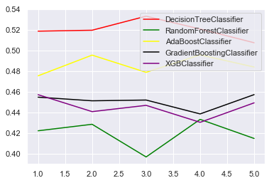

```python
import matplotlib.pyplot as plt
from cycler import cycler
plt.rc('axes', prop_cycle=(cycler('color', ['red', 'green','yellow', 'black','purple'])))
plt.plot(DTC.Fold, DTC.Score)
plt.plot(RFC.Fold, RFC.Score)
plt.plot(ADA.Fold, ADA.Score)
plt.plot(GBC.Fold, GBC.Score)
plt.plot(XGB.Fold, XGB.Score)
plt.legend(['DecisionTreeClassifier', 'RandomForestClassifier', 'AdaBoostClassifier', 'GradientBoostingClassifier','XGBClassifier'], loc='upper right')
plt.show()
```

```python
# classifier list for the downsampled training set
clf_list = [DecisionTreeClassifier(max_depth = 3),
            RandomForestClassifier(n_estimators = 100),
            AdaBoostClassifier(DecisionTreeClassifier(max_depth = 3), n_estimators = 100),
            GradientBoostingClassifier(),
            XGBClassifier()
           ]
# the parameters are set in order to have the same kind of tree every time
```

```python
# use Kfold to evaluate the upsampled training set
kf = KFold(n_splits=5,random_state=42,shuffle=True)

mdl = []
fold = []
scr = []

for i,(train_index, test_index) in enumerate(kf.split(df_downsampled)):
    training = df.iloc[train_index,:]
    valid = df.iloc[test_index,:]
    print(i)
    for clf in clf_list:
        model = clf.__class__.__name__
        feats = training[features] #defined above
        label = training['def_pay']
        valid_feats = valid[features]
        valid_label = valid['def_pay']
        clf.fit(feats,label)
        pred = clf.predict(valid_feats)
        score = f1_score(y_true = valid_label, y_pred = pred)
        fold.append(i+1)
        scr.append(score)
        mdl.append(model)
        print(model)
```

```
0
DecisionTreeClassifier
RandomForestClassifier
AdaBoostClassifier
GradientBoostingClassifier
XGBClassifier
1
DecisionTreeClassifier
RandomForestClassifier
AdaBoostClassifier
GradientBoostingClassifier
XGBClassifier
2
DecisionTreeClassifier
RandomForestClassifier
AdaBoostClassifier
GradientBoostingClassifier
XGBClassifier
3
DecisionTreeClassifier
RandomForestClassifier
AdaBoostClassifier
GradientBoostingClassifier
XGBClassifier
4
DecisionTreeClassifier
RandomForestClassifier
AdaBoostClassifier
GradientBoostingClassifier
XGBClassifier
```

```python
performance = pd.DataFrame({'Model': mdl, 'Score':scr,'Fold':fold})
performance
```

|  | Model | Score | Fold |
| --- | --- | --- | --- |
| 0 | DecisionTreeClassifier | 0.245378 | 1 |
| 1 | RandomForestClassifier | 0.366522 | 1 |
| 2 | AdaBoostClassifier | 0.365239 | 1 |
| 3 | GradientBoostingClassifier | 0.359050 | 1 |
| 4 | XGBClassifier | 0.356612 | 1 |
| 5 | DecisionTreeClassifier | 0.439024 | 2 |
| 6 | RandomForestClassifier | 0.381636 | 2 |
| 7 | AdaBoostClassifier | 0.380228 | 2 |
| 8 | GradientBoostingClassifier | 0.373723 | 2 |
| 9 | XGBClassifier | 0.395924 | 2 |
| 10 | DecisionTreeClassifier | 0.470140 | 3 |
| 11 | RandomForestClassifier | 0.388571 | 3 |
| 12 | AdaBoostClassifier | 0.391626 | 3 |
| 13 | GradientBoostingClassifier | 0.365782 | 3 |
| 14 | XGBClassifier | 0.367713 | 3 |
| 15 | DecisionTreeClassifier | 0.466830 | 4 |
| 16 | RandomForestClassifier | 0.436997 | 4 |
| 17 | AdaBoostClassifier | 0.412396 | 4 |
| 18 | GradientBoostingClassifier | 0.422652 | 4 |
| 19 | XGBClassifier | 0.416667 | 4 |
| 20 | DecisionTreeClassifier | 0.461720 | 5 |
| 21 | RandomForestClassifier | 0.427419 | 5 |
| 22 | AdaBoostClassifier | 0.375598 | 5 |
| 23 | GradientBoostingClassifier | 0.412005 | 5 |
| 24 | XGBClassifier | 0.396694 | 5 |

```python
DTC = performance[performance.Model.isin(["DecisionTreeClassifier"])]
RFC = performance[performance.Model.isin(["RandomForestClassifier"])]
ADA = performance[performance.Model.isin(["AdaBoostClassifier"])]
GBC = performance[performance.Model.isin(["GradientBoostingClassifier"])]
XGB = performance[performance.Model.isin(["XGBClassifier"])]
```

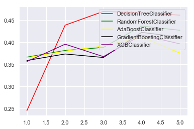

```python
import matplotlib.pyplot as plt
from cycler import cycler
plt.rc('axes', prop_cycle=(cycler('color', ['red', 'green','yellow', 'black','purple'])))
plt.plot(DTC.Fold.values, DTC.Score.values)
plt.plot(RFC.Fold.values, RFC.Score.values)
plt.plot(ADA.Fold.values, ADA.Score.values)
plt.plot(GBC.Fold.values, GBC.Score.values)
plt.plot(XGB.Fold.values, XGB.Score.values)
plt.legend(['DecisionTreeClassifier', 'RandomForestClassifier', 'AdaBoostClassifier', 'GradientBoostingClassifier','XGBClassifier'], loc='upper right')
plt.show()
```

#### Random Forest with different samples

```python
# normal training set
param_grid = {'n_estimators': [200, 400, 600, 1000], # It is going to be a long search
              'criterion': ['entropy', 'gini'],
              'class_weight' : ['balanced'], 'n_jobs' : [-1]} #use all the computational power you have
acc_scorer = make_scorer(f1_score)
grid_forest = GridSearchCV(RandomForestClassifier(), param_grid, scoring = acc_scorer, cv=5)
%time grid_forest = grid_forest.fit(X_train, y_train)
print(grid_forest.best_estimator_)
print(grid_forest.best_score_)
forest_normal = grid_forest.best_estimator_
```

It really takes a long time to run and I run this on the AWS and get the variables and best score:

```python
forest_normal = RandomForestClassifier(bootstrap=True, class_weight='balanced',
            criterion='entropy', max_depth=None, max_features='auto',
            max_leaf_nodes=None, min_impurity_decrease=0.0,
            min_impurity_split=None, min_samples_leaf=1,
            min_samples_split=2, min_weight_fraction_leaf=0.0,
            n_estimators=400, n_jobs=-1, oob_score=False,
            random_state=None, verbose=0, warm_start=False)
print(0.449643478486)
```

```
0.449643478486
```

```python
y_upsampled = df_upsampled.def_pay
X_upsampled = df_upsampled.drop(['def_pay'], axis= 1)
```

```python
# upsampled training set
param_grid = {'n_estimators': [200, 400, 600, 1000],
              'criterion': ['entropy', 'gini'], 'n_jobs' : [-1]}
acc_scorer = make_scorer(f1_score)
grid_forest = GridSearchCV(RandomForestClassifier(), param_grid, scoring = acc_scorer, cv=5)
%time grid_forest = grid_forest.fit(X_upsampled, y_upsampled)
print(grid_forest.best_estimator_)
print(grid_forest.best_score_)
forest_upsampled = grid_forest.best_estimator_
```

```python
forest_upsampled = RandomForestClassifier(bootstrap=True, class_weight=None, criterion='gini',
            max_depth=None, max_features='auto', max_leaf_nodes=None,
            min_impurity_decrease=0.0, min_impurity_split=None,
            min_samples_leaf=1, min_samples_split=2,
            min_weight_fraction_leaf=0.0, n_estimators=600, n_jobs=-1,
            oob_score=False, random_state=None, verbose=0,
            warm_start=False)
print(0.93295704261)
```

```
0.93295704261
```

```python
y_downsampled = df_downsampled.def_pay
X_downsampled = df_downsampled.drop(['def_pay'], axis = 1)
```

```python
# downsampled training set
param_grid = {'n_estimators': [200, 400, 600, 1000],
              'criterion': ['entropy', 'gini'], 'n_jobs' : [-1]}
acc_scorer = make_scorer(f1_score)
grid_forest = GridSearchCV(RandomForestClassifier(), param_grid, scoring = acc_scorer, cv=5)
%time grid_forest = grid_forest.fit(X_downsampled, y_downsampled)
print(grid_forest.best_estimator_)
print(grid_forest.best_score_)
forest_downsampled = grid_forest.best_estimator_
```

```python
forest_downsampled = RandomForestClassifier(bootstrap=True, class_weight=None, criterion='gini',
            max_depth=None, max_features='auto', max_leaf_nodes=None,
            min_impurity_decrease=0.0, min_impurity_split=None,
            min_samples_leaf=1, min_samples_split=2,
            min_weight_fraction_leaf=0.0, n_estimators=1000, n_jobs=-1,
            oob_score=False, random_state=None, verbose=0,
            warm_start=False)
print(0.686692645307)
```

```
0.686692645307
```

```python
# SMOTE training set
param_grid = {'n_estimators': [200, 400, 600, 1000],
              'criterion': ['entropy', 'gini'], 'n_jobs' : [-1]}
acc_scorer = make_scorer(f1_score)
grid_forest = GridSearchCV(RandomForestClassifier(), param_grid, scoring = acc_scorer, cv=5)
%time grid_forest = grid_forest.fit(X_SMOTE, y_SMOTE)
print(grid_forest.best_estimator_)
print(grid_forest.best_score_)
forest_SMOTE = grid_forest.best_estimator_
```

```python
forest_SMOTE = RandomForestClassifier(bootstrap=True, class_weight=None, criterion='gini',
            max_depth=None, max_features='auto', max_leaf_nodes=None,
            min_impurity_decrease=0.0, min_impurity_split=None,
            min_samples_leaf=1, min_samples_split=2,
            min_weight_fraction_leaf=0.0, n_estimators=600, n_jobs=-1,
            oob_score=False, random_state=None, verbose=0,
            warm_start=False)
print(0.831423121548)
```

```
0.831423121548
```

As we can see the result, the upsampling helps a lot as well as SMOTE.

#### Ada Boost Classifier with different samples

```python
# normal training set
param_grid = {'n_estimators': [200,300],
              'algorithm': ['SAMME', 'SAMME.R'],
              'learning_rate' : [0.5, 0.75, 1.0]}
acc_scorer = make_scorer(f1_score)
grid_ada = GridSearchCV(AdaBoostClassifier(DecisionTreeClassifier(class_weight = "balanced")),
                        param_grid, scoring = acc_scorer, cv=5)
%time grid_ada = grid_ada.fit(X_train, y_train)
print(grid_ada.best_estimator_)
print(grid_ada.best_score_)
ada_normal = grid_ada.best_estimator_
```

```python
ada_normal = AdaBoostClassifier(algorithm='SAMME',
          base_estimator=DecisionTreeClassifier(class_weight='balanced', criterion='gini',
            max_depth=None, max_features=None, max_leaf_nodes=None,
            min_impurity_decrease=0.0, min_impurity_split=None,
            min_samples_leaf=1, min_samples_split=2,
            min_weight_fraction_leaf=0.0, presort=False, random_state=None,
            splitter='best'),
          learning_rate=0.75, n_estimators=300, random_state=None)
print(0.408435692436)
```

```
0.408435692436
```

```python
# upsampled training set
param_grid = {'n_estimators': [200,300],
              'algorithm': ['SAMME', 'SAMME.R'],
              'learning_rate' : [0.5, 0.75, 1.0]}
acc_scorer = make_scorer(f1_score)
grid_ada = GridSearchCV(AdaBoostClassifier(), param_grid, scoring = acc_scorer, cv=5)
%time grid_ada = grid_ada.fit(X_upsampled, y_upsampled)
print(grid_ada.best_estimator_)
print(grid_ada.best_score_)
ada_upsampled = grid_ada.best_estimator_
```

```python
ada_upsampled = AdaBoostClassifier(algorithm='SAMME.R', base_estimator=None,
          learning_rate=1.0, n_estimators=300, random_state=None)
print(0.689430792925)
```

```
0.689430792925
```

```python
# downsampled training set
param_grid = {'n_estimators': [200,300],
              'algorithm': ['SAMME', 'SAMME.R'],
              'learning_rate' : [0.5, 0.75, 1.0]}
acc_scorer = make_scorer(f1_score)
grid_ada = GridSearchCV(AdaBoostClassifier(), param_grid, scoring = acc_scorer, cv=5)
%time grid_ada = grid_ada.fit(X_downsampled, y_downsampled)
print(grid_ada.best_estimator_)
print(grid_ada.best_score_)
ada_downsampled = grid_ada.best_estimator_
```

```python
ada_downsampled = AdaBoostClassifier(algorithm='SAMME.R', base_estimator=None,
          learning_rate=1.0, n_estimators=200, random_state=None)
print(0.673783146613)
```

```
0.673783146613
```

```python
# SMOTE training set
param_grid = {'n_estimators': [200,300],
              'algorithm': ['SAMME', 'SAMME.R'],
              'learning_rate' : [0.5, 0.75, 1.0]}
acc_scorer = make_scorer(f1_score)
grid_ada = GridSearchCV(AdaBoostClassifier(), param_grid, scoring = acc_scorer, cv=5)
%time grid_ada = grid_ada.fit(X_SMOTE, y_SMOTE)
print(grid_ada.best_estimator_)
print(grid_ada.best_score_)
ada_SMOTE = grid_ada.best_estimator_
```

```python
ada_SMOTE = AdaBoostClassifier(algorithm='SAMME', base_estimator=None, learning_rate=0.5,
          n_estimators=200, random_state=None)
print(0.797835003041)
```

```
0.797835003041
```

#### Gradient Boost with different samples

```python
# normal training set
param_grid = {'n_estimators': [200,300],
              'learning_rate' : [0.5, 0.75, 1.0]}
acc_scorer = make_scorer(f1_score)
grid_gbc = GridSearchCV(GradientBoostingClassifier(), param_grid, scoring = acc_scorer, cv=5)
%time grid_gbc = grid_gbc.fit(X_train, y_train)
print(grid_gbc.best_estimator_)
print(grid_gbc.best_score_)
gbc_normal = grid_gbc.best_estimator_
```

```python
gbc_normal = GradientBoostingClassifier(criterion='friedman_mse', init=None,
              learning_rate=0.5, loss='deviance', max_depth=3,
              max_features=None, max_leaf_nodes=None,
              min_impurity_decrease=0.0, min_impurity_split=None,
              min_samples_leaf=1, min_samples_split=2,
              min_weight_fraction_leaf=0.0, n_estimators=200,
              presort='auto', random_state=None, subsample=1.0, verbose=0,
              warm_start=False)
print(0.443888650557)
```

```
0.443888650557
```

```python
#upsampled training set
param_grid = {'n_estimators': [200,300],
              'learning_rate' : [0.5, 0.75, 1.0]}
acc_scorer = make_scorer(f1_score)
grid_gbc = GridSearchCV(GradientBoostingClassifier(), param_grid, scoring = acc_scorer, cv=5)
%time grid_gbc = grid_gbc.fit(X_upsampled, y_upsampled)
print(grid_gbc.best_estimator_)
print(grid_gbc.best_score_)
gbc_upsampled = grid_gbc.best_estimator_
```

```python
gbc_upsampled = GradientBoostingClassifier(criterion='friedman_mse', init=None,
              learning_rate=1.0, loss='deviance', max_depth=3,
              max_features=None, max_leaf_nodes=None,
              min_impurity_decrease=0.0, min_impurity_split=None,
              min_samples_leaf=1, min_samples_split=2,
              min_weight_fraction_leaf=0.0, n_estimators=300,
              presort='auto', random_state=None, subsample=1.0, verbose=0,
              warm_start=False)
print(0.831025217754)
```

```
0.831025217754
```

```python
#downsampled training set
param_grid = {'n_estimators': [200,300],
              'learning_rate' : [0.5, 0.75, 1.0]}
acc_scorer = make_scorer(f1_score)
grid_gbc = GridSearchCV(GradientBoostingClassifier(), param_grid, scoring = acc_scorer, cv=5)
%time grid_gbc = grid_gbc.fit(X_downsampled, y_downsampled)
print(grid_gbc.best_estimator_)
print(grid_gbc.best_score_)
gbc_downsampled = grid_gbc.best_estimator_
```

```python
gbc_downsampled = GradientBoostingClassifier(criterion='friedman_mse', init=None,
              learning_rate=0.5, loss='deviance', max_depth=3,
              max_features=None, max_leaf_nodes=None,
              min_impurity_decrease=0.0, min_impurity_split=None,
              min_samples_leaf=1, min_samples_split=2,
              min_weight_fraction_leaf=0.0, n_estimators=300,
              presort='auto', random_state=None, subsample=1.0, verbose=0,
              warm_start=False)
print(0.67183972731)
```

```
0.67183972731
```

```python
#SMOTE training set
param_grid = {'n_estimators': [200,300],
              'learning_rate' : [0.5, 0.75, 1.0]}
acc_scorer = make_scorer(f1_score)
grid_gbc = GridSearchCV(GradientBoostingClassifier(), param_grid, scoring = acc_scorer, cv=5)
%time grid_gbc = grid_gbc.fit(X_SMOTE, y_SMOTE)
print(grid_gbc.best_estimator_)
print(grid_gbc.best_score_)
gbc_SMOTE = grid_gbc.best_estimator_
```

```python
gbc_SMOTE = GradientBoostingClassifier(criterion='friedman_mse', init=None,
              learning_rate=0.5, loss='deviance', max_depth=3,
              max_features=None, max_leaf_nodes=None,
              min_impurity_decrease=0.0, min_impurity_split=None,
              min_samples_leaf=1, min_samples_split=2,
              min_weight_fraction_leaf=0.0, n_estimators=200,
              presort='auto', random_state=None, subsample=1.0, verbose=0,
              warm_start=False)
print(0.78976849349)
```

```
0.78976849349
```

The common result is that the model trained on the normal dataset, which is unbalanced, give a lower f1 score. This also tells me that the a penalized learner (the one with "balanced" options) do not perform as well as one that learned on a balanced sample. The upsampled learners seem to be more promising but, as mentioned, they fall into the overfitting trap more often, so we will see how they perform on the test data.

### Testing

Finally, let us see how does our model perform. I just run all of them and to see whether it can have significant difference.

#### Random Forests

```python
# Normal sample training
%time forest_normal.fit(X_train, y_train)
predictions = forest_normal.predict(X_test)
print("-------------")
print("f1 score: {}".format(round(f1_score(y_true = y_test, y_pred = predictions),3)))
print("Accuracy: {}".format(round(accuracy_score(y_true = y_test, y_pred = predictions),3)))
print("-------------")
print(get_feature_importance(forest_normal, features))
print("-------------")
TP = np.sum(np.logical_and(predictions == 1, y_test == 1))
TN = np.sum(np.logical_and(predictions == 0, y_test == 0))
FP = np.sum(np.logical_and(predictions == 1, y_test == 0))
FN = np.sum(np.logical_and(predictions == 0, y_test == 1))
pred = len(predictions)

print('True Positives: {}'.format(TP))
print('False Positive: {}'.format(FP))
print('True Negative: {}'.format(TN))
print('False Negative: {}'.format(FN))
print('Precision: {}'.format(round(TP/(TP+FP),2)))
print('Recall: {}'.format(round(TP/(TP+FN),2)))
print('Problematic ratio: {}'.format(round(FN/(FN+TP),2)))
```

```
CPU times: user 1min 4s, sys: 344 ms, total: 1min 4s
Wall time: 8.74 s
-------------
f1 score: 0.44
Accuracy: 0.807
-------------
           feat     score
3         PAY_1  0.057467
0     LIMIT_BAL  0.044653
33  Closeness_1  0.041569
28    Avg_exp_1  0.040512
32  Closeness_2  0.038769
9     BILL_AMT1  0.038544
15     PAY_AMT1  0.036157
31  Closeness_3  0.035922
27    Avg_exp_2  0.035429
16     PAY_AMT2  0.034478
30  Closeness_4  0.033845
26    Avg_exp_3  0.033790
29  Closeness_5  0.033602
10    BILL_AMT2  0.033062
25    Avg_exp_4  0.032933
20     PAY_AMT6  0.032692
17     PAY_AMT3  0.032134
24    Avg_exp_5  0.031899
14    BILL_AMT6  0.031432
11    BILL_AMT3  0.031346
18     PAY_AMT4  0.030659
12    BILL_AMT4  0.030582
13    BILL_AMT5  0.030006
19     PAY_AMT5  0.029727
4         PAY_2  0.028117
23        SE_AG  0.020262
5         PAY_3  0.016205
1     EDUCATION  0.015356
21        SE_MA  0.014175
22       AgeBin  0.014159
6         PAY_4  0.013257
7         PAY_5  0.010466
8         PAY_6  0.009287
2      MARRIAGE  0.007507
-------------
True Positives: 454
False Positive: 298
True Negative: 4389
False Negative: 859
Precision: 0.6
Recall: 0.35
Problematic ratio: 0.65
```

```python
# Upsample training
%time forest_upsampled.fit(X_upsampled, y_upsampled)
predictions = forest_upsampled.predict(X_test)
print("-------------")
print("f1 score: {}".format(round(f1_score(y_true = y_test, y_pred = predictions),3)))
print("Accuracy: {}".format(round(accuracy_score(y_true = y_test, y_pred = predictions),3)))
print("-------------")
print(get_feature_importance(forest_upsampled, features))
print("-------------")
TP = np.sum(np.logical_and(predictions == 1, y_test == 1))
TN = np.sum(np.logical_and(predictions == 0, y_test == 0))
FP = np.sum(np.logical_and(predictions == 1, y_test == 0))
FN = np.sum(np.logical_and(predictions == 0, y_test == 1))
pred = len(predictions)

print('True Positives: {}'.format(TP))
print('False Positive: {}'.format(FP))
print('True Negative: {}'.format(TN))
print('False Negative: {}'.format(FN))
print('Precision: {}'.format(round(TP/(TP+FP),2)))
print('Recall: {}'.format(round(TP/(TP+FN),2)))
print('Problematic ratio: {}'.format(round(FN/(FN+TP),2)))
```

```
CPU times: user 1min 40s, sys: 731 ms, total: 1min 40s
Wall time: 13.9 s
-------------
f1 score: 0.487
Accuracy: 0.805
-------------
           feat     score
3         PAY_1  0.071676
0     LIMIT_BAL  0.043792
33  Closeness_1  0.040603
28    Avg_exp_1  0.039101
9     BILL_AMT1  0.037864
32  Closeness_2  0.037635
4         PAY_2  0.035992
15     PAY_AMT1  0.035747
31  Closeness_3  0.035144
27    Avg_exp_2  0.033523
16     PAY_AMT2  0.032889
30  Closeness_4  0.032867
29  Closeness_5  0.032560
10    BILL_AMT2  0.031934
17     PAY_AMT3  0.031896
26    Avg_exp_3  0.031504
20     PAY_AMT6  0.031226
25    Avg_exp_4  0.030789
18     PAY_AMT4  0.029867
24    Avg_exp_5  0.029749
11    BILL_AMT3  0.029608
14    BILL_AMT6  0.029316
12    BILL_AMT4  0.029227
13    BILL_AMT5  0.028835
19     PAY_AMT5  0.028354
5         PAY_3  0.022720
23        SE_AG  0.018937
6         PAY_4  0.014968
1     EDUCATION  0.014407
22       AgeBin  0.013592
21        SE_MA  0.013373
7         PAY_5  0.012666
8         PAY_6  0.010514
2      MARRIAGE  0.007127
-------------
True Positives: 556
False Positive: 413
True Negative: 4274
False Negative: 757
Precision: 0.57
Recall: 0.42
Problematic ratio: 0.58
```

```python
# Downsample training
%time forest_downsampled.fit(X_downsampled, y_downsampled)
predictions = forest_downsampled.predict(X_test)
print("-------------")
print("f1 score: {}".format(round(f1_score(y_true = y_test, y_pred = predictions),3)))
print("Accuracy: {}".format(round(accuracy_score(y_true = y_test, y_pred = predictions),3)))
print("-------------")
print(get_feature_importance(forest_downsampled, features))
print("-------------")
TP = np.sum(np.logical_and(predictions == 1, y_test == 1))
TN = np.sum(np.logical_and(predictions == 0, y_test == 0))
FP = np.sum(np.logical_and(predictions == 1, y_test == 0))
FN = np.sum(np.logical_and(predictions == 0, y_test == 1))
pred = len(predictions)

print('True Positives: {}'.format(TP))
print('False Positive: {}'.format(FP))
print('True Negative: {}'.format(TN))
print('False Negative: {}'.format(FN))
print('Precision: {}'.format(round(TP/(TP+FP),2)))
print('Recall: {}'.format(round(TP/(TP+FN),2)))
print('Problematic ratio: {}'.format(round(FN/(FN+TP),2)))
```

```
CPU times: user 47.3 s, sys: 451 ms, total: 47.7 s
Wall time: 6.88 s
-------------
f1 score: 0.512
Accuracy: 0.732
-------------
           feat     score
3         PAY_1  0.072488
0     LIMIT_BAL  0.043273
33  Closeness_1  0.041135
28    Avg_exp_1  0.038122
9     BILL_AMT1  0.037974
32  Closeness_2  0.037936
4         PAY_2  0.036322
15     PAY_AMT1  0.035032
31  Closeness_3  0.033883
27    Avg_exp_2  0.033788
30  Closeness_4  0.032770
16     PAY_AMT2  0.032621
29  Closeness_5  0.032459
17     PAY_AMT3  0.032115
20     PAY_AMT6  0.031891
10    BILL_AMT2  0.031597
26    Avg_exp_3  0.031179
25    Avg_exp_4  0.030124
24    Avg_exp_5  0.029565
11    BILL_AMT3  0.029254
14    BILL_AMT6  0.029160
19     PAY_AMT5  0.028914
12    BILL_AMT4  0.028496
13    BILL_AMT5  0.028390
18     PAY_AMT4  0.028332
5         PAY_3  0.023417
23        SE_AG  0.020232
1     EDUCATION  0.015683
6         PAY_4  0.015008
21        SE_MA  0.014729
22       AgeBin  0.014610
8         PAY_6  0.011157
7         PAY_5  0.010538
2      MARRIAGE  0.007807
-------------
True Positives: 845
False Positive: 1140
True Negative: 3547
False Negative: 468
Precision: 0.43
Recall: 0.64
Problematic ratio: 0.36
```

```python
# SMOTE training
%time forest_SMOTE.fit(X_SMOTE, y_SMOTE)
predictions = forest_SMOTE.predict(X_test)
print("-------------")
print("f1 score: {}".format(round(f1_score(y_true = y_test, y_pred = predictions),3)))
print("Accuracy: {}".format(round(accuracy_score(y_true = y_test, y_pred = predictions),3)))
print("-------------")
print(get_feature_importance(forest_SMOTE, features))
print("-------------")
TP = np.sum(np.logical_and(predictions == 1, y_test == 1))
TN = np.sum(np.logical_and(predictions == 0, y_test == 0))
FP = np.sum(np.logical_and(predictions == 1, y_test == 0))
FN = np.sum(np.logical_and(predictions == 0, y_test == 1))
pred = len(predictions)

print('True Positives: {}'.format(TP))
print('False Positive: {}'.format(FP))
print('True Negative: {}'.format(TN))
print('False Negative: {}'.format(FN))
print('Precision: {}'.format(round(TP/(TP+FP),2)))
print('Recall: {}'.format(round(TP/(TP+FN),2)))
print('Problematic ratio: {}'.format(round(FN/(FN+TP),2)))
```

```
CPU times: user 1min 48s, sys: 606 ms, total: 1min 49s
Wall time: 14.8 s
-------------
f1 score: 0.489
Accuracy: 0.812
-------------
           feat     score
3         PAY_1  0.134354
4         PAY_2  0.064561
21        SE_MA  0.046780
2      MARRIAGE  0.046674
5         PAY_3  0.043610
1     EDUCATION  0.037023
6         PAY_4  0.033278
23        SE_AG  0.030646
22       AgeBin  0.030282
0     LIMIT_BAL  0.029743
33  Closeness_1  0.026695
9     BILL_AMT1  0.025823
15     PAY_AMT1  0.025309
7         PAY_5  0.024755
28    Avg_exp_1  0.024004
32  Closeness_2  0.023567
16     PAY_AMT2  0.021955
17     PAY_AMT3  0.021138
31  Closeness_3  0.021120
20     PAY_AMT6  0.020713
10    BILL_AMT2  0.020282
27    Avg_exp_2  0.020261
18     PAY_AMT4  0.019874
30  Closeness_4  0.019726
29  Closeness_5  0.019631
8         PAY_6  0.019259
19     PAY_AMT5  0.019216
11    BILL_AMT3  0.019172
14    BILL_AMT6  0.018903
26    Avg_exp_3  0.018849
13    BILL_AMT5  0.018730
12    BILL_AMT4  0.018614
25    Avg_exp_4  0.017913
24    Avg_exp_5  0.017537
-------------
True Positives: 541
False Positive: 359
True Negative: 4328
False Negative: 772
Precision: 0.6
Recall: 0.41
Problematic ratio: 0.59
```

#### Ada Boost

```python
# Normal sample training
%time ada_normal.fit(X_train, y_train)
predictions = ada_normal.predict(X_test)
print("-------------")
print("f1 score: {}".format(round(f1_score(y_true = y_test, y_pred = predictions),3)))
print("Accuracy: {}".format(round(accuracy_score(y_true = y_test, y_pred = predictions),3)))
print("-------------")
print(get_feature_importance(ada_normal, features))
print("-------------")
TP = np.sum(np.logical_and(predictions == 1, y_test == 1))
TN = np.sum(np.logical_and(predictions == 0, y_test == 0))
FP = np.sum(np.logical_and(predictions == 1, y_test == 0))
FN = np.sum(np.logical_and(predictions == 0, y_test == 1))
pred = len(predictions)

print('True Positives: {}'.format(TP))
print('False Positive: {}'.format(FP))
print('True Negative: {}'.format(TN))
print('False Negative: {}'.format(FN))
print('Precision: {}'.format(round(TP/(TP+FP),2)))
print('Recall: {}'.format(round(TP/(TP+FN),2)))
print('Problematic ratio: {}'.format(round(FN/(FN+TP),2)))
```

```
CPU times: user 26.6 s, sys: 115 ms, total: 26.7 s
Wall time: 26.8 s
-------------
f1 score: 0.418
Accuracy: 0.78
-------------
           feat     score
3         PAY_1  0.082618
4         PAY_2  0.075010
0     LIMIT_BAL  0.063391
28    Avg_exp_1  0.049637
33  Closeness_1  0.047612
32  Closeness_2  0.035227
16     PAY_AMT2  0.034883
20     PAY_AMT6  0.034663
17     PAY_AMT3  0.033819
25    Avg_exp_4  0.033384
9     BILL_AMT1  0.032827
24    Avg_exp_5  0.032150
15     PAY_AMT1  0.031003
18     PAY_AMT4  0.030251
31  Closeness_3  0.029358
19     PAY_AMT5  0.029158
23        SE_AG  0.028905
27    Avg_exp_2  0.026894
30  Closeness_4  0.026751
26    Avg_exp_3  0.026245
14    BILL_AMT6  0.025316
1     EDUCATION  0.024264
29  Closeness_5  0.024130
10    BILL_AMT2  0.023172
11    BILL_AMT3  0.019517
13    BILL_AMT5  0.019512
12    BILL_AMT4  0.018075
22       AgeBin  0.017325
21        SE_MA  0.016520
6         PAY_4  0.009681
2      MARRIAGE  0.006844
8         PAY_6  0.005289
5         PAY_3  0.004278
7         PAY_5  0.002287
-------------
True Positives: 474
False Positive: 483
True Negative: 4204
False Negative: 839
Precision: 0.5
Recall: 0.36
Problematic ratio: 0.64
```

```python
# Upsample training
%time ada_upsampled.fit(X_upsampled, y_upsampled)
predictions = ada_upsampled.predict(X_test)
print("-------------")
print("f1 score: {}".format(round(f1_score(y_true = y_test, y_pred = predictions),3)))
print("Accuracy: {}".format(round(accuracy_score(y_true = y_test, y_pred = predictions),3)))
print("-------------")
print(get_feature_importance(ada_upsampled, features))
print("-------------")
TP = np.sum(np.logical_and(predictions == 1, y_test == 1))
TN = np.sum(np.logical_and(predictions == 0, y_test == 0))
FP = np.sum(np.logical_and(predictions == 1, y_test == 0))
FN = np.sum(np.logical_and(predictions == 0, y_test == 1))
pred = len(predictions)

print('True Positives: {}'.format(TP))
print('False Positive: {}'.format(FP))
print('True Negative: {}'.format(TN))
print('False Negative: {}'.format(FN))
print('Precision: {}'.format(round(TP/(TP+FP),2)))
print('Recall: {}'.format(round(TP/(TP+FN),2)))
print('Problematic ratio: {}'.format(round(FN/(FN+TP),2)))
```

```
CPU times: user 21.8 s, sys: 175 ms, total: 22 s
Wall time: 22.1 s
-------------
f1 score: 0.524
Accuracy: 0.751
-------------
           feat     score
16     PAY_AMT2  0.083333
32  Closeness_2  0.063333
29  Closeness_5  0.063333
28    Avg_exp_1  0.063333
31  Closeness_3  0.046667
26    Avg_exp_3  0.046667
24    Avg_exp_5  0.046667
11    BILL_AMT3  0.046667
30  Closeness_4  0.043333
20     PAY_AMT6  0.043333
13    BILL_AMT5  0.043333
33  Closeness_1  0.040000
9     BILL_AMT1  0.040000
14    BILL_AMT6  0.040000
10    BILL_AMT2  0.036667
15     PAY_AMT1  0.036667
17     PAY_AMT3  0.030000
12    BILL_AMT4  0.030000
0     LIMIT_BAL  0.026667
18     PAY_AMT4  0.026667
27    Avg_exp_2  0.026667
25    Avg_exp_4  0.016667
19     PAY_AMT5  0.016667
6         PAY_4  0.010000
3         PAY_1  0.010000
21        SE_MA  0.006667
22       AgeBin  0.003333
8         PAY_6  0.003333
5         PAY_3  0.003333
2      MARRIAGE  0.003333
1     EDUCATION  0.003333
23        SE_AG  0.000000
7         PAY_5  0.000000
4         PAY_2  0.000000
-------------
True Positives: 821
False Positive: 1001
True Negative: 3686
False Negative: 492
Precision: 0.45
Recall: 0.63
Problematic ratio: 0.37
```

```python
# Downsample training
%time ada_downsampled.fit(X_downsampled, y_downsampled)
predictions = ada_downsampled.predict(X_test)
print("-------------")
print("f1 score: {}".format(round(f1_score(y_true = y_test, y_pred = predictions),3)))
print("Accuracy: {}".format(round(accuracy_score(y_true = y_test, y_pred = predictions),3)))
print("-------------")
print(get_feature_importance(ada_downsampled, features))
print("-------------")
TP = np.sum(np.logical_and(predictions == 1, y_test == 1))
TN = np.sum(np.logical_and(predictions == 0, y_test == 0))
FP = np.sum(np.logical_and(predictions == 1, y_test == 0))
FN = np.sum(np.logical_and(predictions == 0, y_test == 1))
pred = len(predictions)

print('True Positives: {}'.format(TP))
print('False Positive: {}'.format(FP))
print('True Negative: {}'.format(TN))
print('False Negative: {}'.format(FN))
print('Precision: {}'.format(round(TP/(TP+FP),2)))
print('Recall: {}'.format(round(TP/(TP+FN),2)))
print('Problematic ratio: {}'.format(round(FN/(FN+TP),2)))
```

```
CPU times: user 4.52 s, sys: 27 ms, total: 4.55 s
Wall time: 4.56 s
-------------
f1 score: 0.513
Accuracy: 0.734
-------------
           feat  score
33  Closeness_1  0.075
31  Closeness_3  0.075
30  Closeness_4  0.075
9     BILL_AMT1  0.060
28    Avg_exp_1  0.060
24    Avg_exp_5  0.055
17     PAY_AMT3  0.055
16     PAY_AMT2  0.050
18     PAY_AMT4  0.050
27    Avg_exp_2  0.045
11    BILL_AMT3  0.040
29  Closeness_5  0.040
26    Avg_exp_3  0.040
12    BILL_AMT4  0.035
32  Closeness_2  0.030
10    BILL_AMT2  0.030
13    BILL_AMT5  0.030
25    Avg_exp_4  0.025
0     LIMIT_BAL  0.020
14    BILL_AMT6  0.020
15     PAY_AMT1  0.020
5         PAY_3  0.010
3         PAY_1  0.010
20     PAY_AMT6  0.010
19     PAY_AMT5  0.010
1     EDUCATION  0.010
22       AgeBin  0.005
21        SE_MA  0.005
8         PAY_6  0.005
2      MARRIAGE  0.005
23        SE_AG  0.000
4         PAY_2  0.000
6         PAY_4  0.000
7         PAY_5  0.000
-------------
True Positives: 841
False Positive: 1125
True Negative: 3562
False Negative: 472
Precision: 0.43
Recall: 0.64
Problematic ratio: 0.36
```

```python
# SMOTE training
%time ada_SMOTE.fit(X_SMOTE, y_SMOTE)
predictions = ada_SMOTE.predict(X_test)
print("-------------")
print("f1 score: {}".format(round(f1_score(y_true = y_test, y_pred = predictions),3)))
print("Accuracy: {}".format(round(accuracy_score(y_true = y_test, y_pred = predictions),3)))
print("-------------")
print(get_feature_importance(ada_SMOTE, features))
print("-------------")
TP = np.sum(np.logical_and(predictions == 1, y_test == 1))
TN = np.sum(np.logical_and(predictions == 0, y_test == 0))
FP = np.sum(np.logical_and(predictions == 1, y_test == 0))
FN = np.sum(np.logical_and(predictions == 0, y_test == 1))
pred = len(predictions)

print('True Positives: {}'.format(TP))
print('False Positive: {}'.format(FP))
print('True Negative: {}'.format(TN))
print('False Negative: {}'.format(FN))
print('Precision: {}'.format(round(TP/(TP+FP),2)))
print('Recall: {}'.format(round(TP/(TP+FN),2)))
print('Problematic ratio: {}'.format(round(FN/(FN+TP),2)))
```

```
CPU times: user 19.9 s, sys: 74.7 ms, total: 20 s
Wall time: 20 s
-------------
f1 score: 0.479
Accuracy: 0.802
-------------
           feat     score
1     EDUCATION  0.241015
2      MARRIAGE  0.176700
22       AgeBin  0.146142
3         PAY_1  0.138198
21        SE_MA  0.063671
23        SE_AG  0.040795
16     PAY_AMT2  0.033733
5         PAY_3  0.029580
4         PAY_2  0.023501
6         PAY_4  0.021063
8         PAY_6  0.015983
32  Closeness_2  0.013789
7         PAY_5  0.011850
17     PAY_AMT3  0.009906
28    Avg_exp_1  0.009458
18     PAY_AMT4  0.008043
20     PAY_AMT6  0.005375
15     PAY_AMT1  0.004665
9     BILL_AMT1  0.003993
33  Closeness_1  0.002542
19     PAY_AMT5  0.000000
14    BILL_AMT6  0.000000
13    BILL_AMT5  0.000000
12    BILL_AMT4  0.000000
24    Avg_exp_5  0.000000
25    Avg_exp_4  0.000000
26    Avg_exp_3  0.000000
27    Avg_exp_2  0.000000
11    BILL_AMT3  0.000000
29  Closeness_5  0.000000
30  Closeness_4  0.000000
31  Closeness_3  0.000000
10    BILL_AMT2  0.000000
0     LIMIT_BAL  0.000000
-------------
True Positives: 546
False Positive: 422
True Negative: 4265
False Negative: 767
Precision: 0.56
Recall: 0.42
Problematic ratio: 0.58
```

#### Gradient Boosting

```python
# Normal sample training
%time gbc_normal.fit(X_train, y_train)
predictions = gbc_normal.predict(X_test)
print("-------------")
print("f1 score: {}".format(round(f1_score(y_true = y_test, y_pred = predictions),3)))
print("Accuracy: {}".format(round(accuracy_score(y_true = y_test, y_pred = predictions),3)))
print("-------------")
print(get_feature_importance(gbc_normal, features))
print("-------------")
TP = np.sum(np.logical_and(predictions == 1, y_test == 1))
TN = np.sum(np.logical_and(predictions == 0, y_test == 0))
FP = np.sum(np.logical_and(predictions == 1, y_test == 0))
FN = np.sum(np.logical_and(predictions == 0, y_test == 1))
pred = len(predictions)

print('True Positives: {}'.format(TP))
print('False Positive: {}'.format(FP))
print('True Negative: {}'.format(TN))
print('False Negative: {}'.format(FN))
print('Precision: {}'.format(round(TP/(TP+FP),2)))
print('Recall: {}'.format(round(TP/(TP+FN),2)))
print('Problematic ratio: {}'.format(round(FN/(FN+TP),2)))
```

```
CPU times: user 8.49 s, sys: 75.7 ms, total: 8.57 s
Wall time: 8.59 s
-------------
f1 score: 0.453
Accuracy: 0.803
-------------
           feat     score
3         PAY_1  0.320987
33  Closeness_1  0.081665
28    Avg_exp_1  0.048627
9     BILL_AMT1  0.041601
32  Closeness_2  0.039146
30  Closeness_4  0.025560
29  Closeness_5  0.025092
0     LIMIT_BAL  0.024626
17     PAY_AMT3  0.022839
6         PAY_4  0.022594
15     PAY_AMT1  0.022019
26    Avg_exp_3  0.022010
20     PAY_AMT6  0.021151
14    BILL_AMT6  0.021090
16     PAY_AMT2  0.020978
24    Avg_exp_5  0.020592
27    Avg_exp_2  0.018775
31  Closeness_3  0.018346
4         PAY_2  0.017933
25    Avg_exp_4  0.017718
5         PAY_3  0.017352
12    BILL_AMT4  0.015996
7         PAY_5  0.015474
13    BILL_AMT5  0.015043
19     PAY_AMT5  0.014751
10    BILL_AMT2  0.014298
11    BILL_AMT3  0.011557
18     PAY_AMT4  0.011375
8         PAY_6  0.008505
23        SE_AG  0.005582
21        SE_MA  0.005124
22       AgeBin  0.004482
2      MARRIAGE  0.003780
1     EDUCATION  0.003333
-------------
True Positives: 489
False Positive: 359
True Negative: 4328
False Negative: 824
Precision: 0.58
Recall: 0.37
Problematic ratio: 0.63
```

```python
# Upsample training
%time gbc_upsampled.fit(X_upsampled, y_upsampled)
predictions = gbc_upsampled.predict(X_test)
print("-------------")
print("f1 score: {}".format(round(f1_score(y_true = y_test, y_pred = predictions),3)))
print("Accuracy: {}".format(round(accuracy_score(y_true = y_test, y_pred = predictions),3)))
print("-------------")
print(get_feature_importance(gbc_upsampled, features))
print("-------------")
TP = np.sum(np.logical_and(predictions == 1, y_test == 1))
TN = np.sum(np.logical_and(predictions == 0, y_test == 0))
FP = np.sum(np.logical_and(predictions == 1, y_test == 0))
FN = np.sum(np.logical_and(predictions == 0, y_test == 1))
pred = len(predictions)

print('True Positives: {}'.format(TP))
print('False Positive: {}'.format(FP))
print('True Negative: {}'.format(TN))
print('False Negative: {}'.format(FN))
print('Precision: {}'.format(round(TP/(TP+FP),2)))
print('Recall: {}'.format(round(TP/(TP+FN),2)))
print('Problematic ratio: {}'.format(round(FN/(FN+TP),2)))
```

```
CPU times: user 18.6 s, sys: 195 ms, total: 18.8 s
Wall time: 18.8 s
-------------
f1 score: 0.468
Accuracy: 0.732
-------------
           feat     score
3         PAY_1  0.259826
33  Closeness_1  0.057499
17     PAY_AMT3  0.053915
28    Avg_exp_1  0.048582
32  Closeness_2  0.038668
16     PAY_AMT2  0.032403
0     LIMIT_BAL  0.030652
30  Closeness_4  0.030384
29  Closeness_5  0.029796
25    Avg_exp_4  0.029261
9     BILL_AMT1  0.029007
15     PAY_AMT1  0.028794
26    Avg_exp_3  0.028034
24    Avg_exp_5  0.027830
20     PAY_AMT6  0.026333
31  Closeness_3  0.026214
27    Avg_exp_2  0.025790
11    BILL_AMT3  0.022673
14    BILL_AMT6  0.021380
18     PAY_AMT4  0.019963
12    BILL_AMT4  0.019563
10    BILL_AMT2  0.018143
13    BILL_AMT5  0.017728
19     PAY_AMT5  0.017522
7         PAY_5  0.015021
5         PAY_3  0.009160
1     EDUCATION  0.008972
21        SE_MA  0.006705
4         PAY_2  0.005433
23        SE_AG  0.004838
6         PAY_4  0.004006
22       AgeBin  0.003038
2      MARRIAGE  0.002229
8         PAY_6  0.000637
-------------
True Positives: 710
False Positive: 1008
True Negative: 3679
False Negative: 603
Precision: 0.41
Recall: 0.54
Problematic ratio: 0.46
```

```python
# Downsample training
%time gbc_downsampled.fit(X_downsampled, y_downsampled)
predictions = gbc_downsampled.predict(X_test)
print("-------------")
print("f1 score: {}".format(round(f1_score(y_true = y_test, y_pred = predictions),3)))
print("Accuracy: {}".format(round(accuracy_score(y_true = y_test, y_pred = predictions),3)))
print("-------------")
print(get_feature_importance(gbc_downsampled, features))
print("-------------")
TP = np.sum(np.logical_and(predictions == 1, y_test == 1))
TN = np.sum(np.logical_and(predictions == 0, y_test == 0))
FP = np.sum(np.logical_and(predictions == 1, y_test == 0))
FN = np.sum(np.logical_and(predictions == 0, y_test == 1))
pred = len(predictions)

print('True Positives: {}'.format(TP))
print('False Positive: {}'.format(FP))
print('True Negative: {}'.format(TN))
print('False Negative: {}'.format(FN))
print('Precision: {}'.format(round(TP/(TP+FP),2)))
print('Recall: {}'.format(round(TP/(TP+FN),2)))
print('Problematic ratio: {}'.format(round(FN/(FN+TP),2)))
```

```
CPU times: user 5.53 s, sys: 34.2 ms, total: 5.56 s
Wall time: 5.59 s
-------------
f1 score: 0.482
Accuracy: 0.681
-------------
           feat     score
3         PAY_1  0.253949
33  Closeness_1  0.053876
28    Avg_exp_1  0.050632
32  Closeness_2  0.047043
9     BILL_AMT1  0.044265
17     PAY_AMT3  0.044159
16     PAY_AMT2  0.036593
25    Avg_exp_4  0.029043
29  Closeness_5  0.028850
26    Avg_exp_3  0.027461
15     PAY_AMT1  0.026659
31  Closeness_3  0.025654
24    Avg_exp_5  0.025196
0     LIMIT_BAL  0.023802
27    Avg_exp_2  0.023782
14    BILL_AMT6  0.023555
18     PAY_AMT4  0.021630
30  Closeness_4  0.021182
11    BILL_AMT3  0.021027
20     PAY_AMT6  0.020939
10    BILL_AMT2  0.020374
19     PAY_AMT5  0.018044
13    BILL_AMT5  0.017747
6         PAY_4  0.016114
5         PAY_3  0.016002
12    BILL_AMT4  0.014903
8         PAY_6  0.009952
4         PAY_2  0.008572
1     EDUCATION  0.007027
21        SE_MA  0.006340
23        SE_AG  0.005774
2      MARRIAGE  0.005641
22       AgeBin  0.003063
7         PAY_5  0.001153
-------------
True Positives: 890
False Positive: 1492
True Negative: 3195
False Negative: 423
Precision: 0.37
Recall: 0.68
Problematic ratio: 0.32
```

```python
# SMOTE training
%time gbc_SMOTE.fit(X_SMOTE, y_SMOTE)
predictions = gbc_SMOTE.predict(X_test)
print("-------------")
print("f1 score: {}".format(round(f1_score(y_true = y_test, y_pred = predictions),3)))
print("Accuracy: {}".format(round(accuracy_score(y_true = y_test, y_pred = predictions),3)))
print("-------------")
print(get_feature_importance(gbc_SMOTE, features))
print("-------------")
TP = np.sum(np.logical_and(predictions == 1, y_test == 1))
TN = np.sum(np.logical_and(predictions == 0, y_test == 0))
FP = np.sum(np.logical_and(predictions == 1, y_test == 0))
FN = np.sum(np.logical_and(predictions == 0, y_test == 1))
pred = len(predictions)

print('True Positives: {}'.format(TP))
print('False Positive: {}'.format(FP))
print('True Negative: {}'.format(TN))
print('False Negative: {}'.format(FN))
print('Precision: {}'.format(round(TP/(TP+FP),2)))
print('Recall: {}'.format(round(TP/(TP+FN),2)))
print('Problematic ratio: {}'.format(round(FN/(FN+TP),2)))
```

```
CPU times: user 17.6 s, sys: 139 ms, total: 17.7 s
Wall time: 17.8 s
-------------
f1 score: 0.454
Accuracy: 0.8
-------------
           feat     score
3         PAY_1  0.480474
2      MARRIAGE  0.107266
5         PAY_3  0.062811
1     EDUCATION  0.049239
21        SE_MA  0.048411
4         PAY_2  0.042012
23        SE_AG  0.036966
33  Closeness_1  0.018677
15     PAY_AMT1  0.015647
22       AgeBin  0.014860
32  Closeness_2  0.010923
6         PAY_4  0.009748
27    Avg_exp_2  0.009561
8         PAY_6  0.009074
28    Avg_exp_1  0.007615
9     BILL_AMT1  0.007300
17     PAY_AMT3  0.007203
24    Avg_exp_5  0.005009
7         PAY_5  0.004900
16     PAY_AMT2  0.004882
29  Closeness_5  0.004652
18     PAY_AMT4  0.004518
0     LIMIT_BAL  0.004443
20     PAY_AMT6  0.004086
26    Avg_exp_3  0.003662
30  Closeness_4  0.003335
11    BILL_AMT3  0.003208
25    Avg_exp_4  0.003188
13    BILL_AMT5  0.003141
19     PAY_AMT5  0.002897
14    BILL_AMT6  0.002660
10    BILL_AMT2  0.002596
12    BILL_AMT4  0.002561
31  Closeness_3  0.002475
-------------
True Positives: 499
False Positive: 387
True Negative: 4300
False Negative: 814
Precision: 0.56
Recall: 0.38
Problematic ratio: 0.62
```

### Conclusions:

To be honest, the results are not good. The problem may happen in the feature engineering part. I literally try every models I learned but still does not perform well.

In this project, I learned how important it is for checking the data unbalancing. And after visualizing the features and understand the relationship between different features.

When I use the models and test the f1 score, I am thinking about that banks do not care about the false negatives if they just want to know the default of the costumers but if the banks are interested in preventing these guys(which I guess they want to). FN will be much more relevant.

To improve this, I searched around and tried to find the best threshold with best f1 score. After that I find some thing interesting is: I evaluated by using the f1-score indicator. Choosing the highest score `rarely` is my goal. In order to do this, I probably need to create another function to minimize the TP FP TN FN.

However, it could be a very good starting point for me. After this project, the results I got are not wasting my time since I know more about how to build a model and in this process, I understand how important it is and how to preprocess the dataset.

This is a really interesting and useful experience for me and even for the real life. Since now along with the deposit comes up, banks should very care about the costumers who default and how the life influence them. This will definitely help them when they judge how many credit should they give to one person. Remember how Lehman Brothers bankrupt? The root reason is "The subprime mortgage crisis caused the financial products it held to become bad debts" and then do not prevent the bad debts well.

```python
pred_val_y = 0.6 * pred_val_lstm_y + 0.4 * pred_val_cnn_y
pred_test_y = 0.6 * pred_test_lstm_y + 0.4 * pred_test_cnn_y

thresholds = []
for thresh in np.arange(0.1, 0.501, 0.01):
    thresh = np.round(thresh, 2)
    res = metrics.f1_score(val_y, (pred_val_y > thresh).astype(int))
    thresholds.append([thresh, res])
    print("F1 score at threshold {0} is {1}".format(thresh, res))

thresholds.sort(key=lambda x: x[1], reverse=True)
best_thresh = thresholds[0][0]
print("Best threshold: ", best_thresh)
```

And then, here is another kernel. For improving the result, let's try ROC AUC for this time:

Setting parameters:

```python
RFC_METRIC = 'gini'  #metric used for RandomForrestClassifier
NUM_ESTIMATORS = 100 #number of estimators used for RandomForrestClassifier
NO_JOBS = 4 #number of parallel jobs used for RandomForrestClassifier

#VALIDATION
VALID_SIZE = 0.20 # simple validation using train_test_split

#CROSS-VALIDATION
NUMBER_KFOLDS = 5 #number of KFolds for cross-validation

RANDOM_STATE = 2018
```

Loading data:

```python
data_df = pd.read_csv("UCI_Credit_Card.csv")
```

## Models:

#### Define predictors and target values

Let's define the predictor features and the target features. Categorical features, if any, are also defined. In our case, there are no categorical feature.

```python
target = 'default.payment.next.month'
predictors = [  'LIMIT_BAL', 'SEX', 'EDUCATION', 'MARRIAGE', 'AGE',
                'PAY_0', 'PAY_2', 'PAY_3', 'PAY_4', 'PAY_5', 'PAY_6',
                'BILL_AMT1','BILL_AMT2', 'BILL_AMT3', 'BILL_AMT4', 'BILL_AMT5', 'BILL_AMT6',
                'PAY_AMT1', 'PAY_AMT2', 'PAY_AMT3', 'PAY_AMT4', 'PAY_AMT5', 'PAY_AMT6']
```

#### Split data into train and validation set:

```python
train_df, val_df = train_test_split(data_df, test_size=VALID_SIZE, random_state=RANDOM_STATE, shuffle=True )
```

For, safety, I make copies of the train and validation set

```python
train_df_bkp = train_df.copy()
val_df_bkp = val_df.copy()
```

### RandomForestClassifier:

Let's run a model using the training set for training. Then, we will use the validation set for validation.

Metric

We will use as validation criterion GINI, which formula is $$GINI = 2 * (AUC) - 1$$AUC is the Receiver Operating Characteristic - Area Under Curve $$ROC-AUC$$ Number of estimators is set to 100 and number of parallel jobs is set to 4.

```python
clf = RandomForestClassifier(n_jobs=NO_JOBS,
                             random_state=RANDOM_STATE,
                             criterion=RFC_METRIC,
                             n_estimators=NUM_ESTIMATORS,
                             verbose=False)
```

Let's train the RandonForestClassifier using the train_df data and fit function.

```python
clf.fit(train_df[predictors], train_df[target].values)
```

```
RandomForestClassifier(bootstrap=True, class_weight=None, criterion='gini',
            max_depth=None, max_features='auto', max_leaf_nodes=None,
            min_impurity_decrease=0.0, min_impurity_split=None,
            min_samples_leaf=1, min_samples_split=2,
            min_weight_fraction_leaf=0.0, n_estimators=100, n_jobs=4,
            oob_score=False, random_state=2018, verbose=False,
            warm_start=False)
```

Let's now predict the target values for the val_df data, using predict function.

#### Features importance

And let's see the features importance,

```python
preds = clf.predict(val_df[predictors])
```

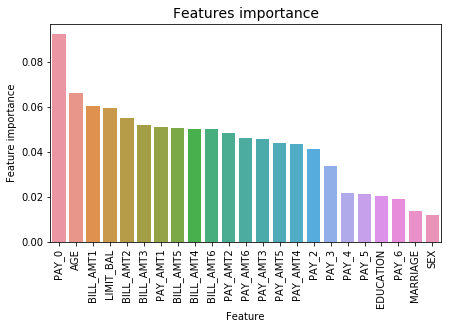

```python
tmp = pd.DataFrame({'Feature': predictors, 'Feature importance': clf.feature_importances_})
tmp = tmp.sort_values(by='Feature importance',ascending=False)
plt.figure(figsize = (7,4))
plt.title('Features importance',fontsize=14)
s = sns.barplot(x='Feature',y='Feature importance',data=tmp)
s.set_xticklabels(s.get_xticklabels(),rotation=90)
plt.show()
```

So, we can see that the most important features are PAY_0, AGE, BILL_AMT1, LIMIT_BAL, BILL_AMT2, BILL_AMT3.

#### Confusion Matrix

Let's show a confusion matrix for the results we obtained.

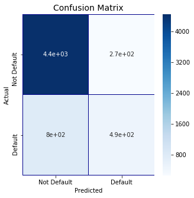

```python
cm = pd.crosstab(val_df[target].values, preds, rownames=['Actual'], colnames=['Predicted'])
fig, (ax1) = plt.subplots(ncols=1, figsize=(5,5))
sns.heatmap(cm,
            xticklabels=['Not Default', 'Default'],
            yticklabels=['Not Default', 'Default'],
            annot=True,ax=ax1,
            linewidths=.2,linecolor="Darkblue", cmap="Blues")
plt.title('Confusion Matrix', fontsize=14)
plt.show()
```

#### ROC AUC Calculate:

```python
roc_auc_score(val_df[target].values, preds)
```

```
0.6625018741566295
```

So, as the result the ROC-AUC score obtained with RandomForrestClassifier is 0.66.

Let's use for RandomForrestClassifier dummified variables for the categorical features.

We start by defining the categorical features.

#### RandomForrest with OneHotEncoder:

```python
cat_features = ['EDUCATION', 'SEX', 'MARRIAGE', 'PAY_0', 'PAY_2', 'PAY_3', 'PAY_4', 'PAY_5', 'PAY_6']
```

```python
train_f_df = pd.get_dummies(train_df_bkp, columns = cat_features)
val_f_df = pd.get_dummies(val_df_bkp, columns = cat_features)
```

```python
print("Default of Credit Card Clients train data -  rows:",train_f_df.shape[0]," columns:", train_f_df.shape[1])
print("Default of Credit Card Clients val  data -  rows:",val_f_df.shape[0]," columns:", val_f_df.shape[1])
```

```
Default of Credit Card Clients train data -  rows: 24000  columns: 93
Default of Credit Card Clients val  data -  rows: 6000  columns: 86
```

As we can see, they do not have the same number of columns, so we need to unify them:

```python
train_fa_df, val_fa_df = train_f_df.align(val_f_df, join='outer', axis=1, fill_value=0)
```

```python
print("Default of Credit Card Clients train data -  rows:",train_fa_df.shape[0]," columns:", train_fa_df.shape[1])
print("Default of Credit Card Clients val  data -  rows:",val_fa_df.shape[0]," columns:", val_fa_df.shape[1])
```

```
Default of Credit Card Clients train data -  rows: 24000  columns: 93
Default of Credit Card Clients val  data -  rows: 6000  columns: 93
```

Now, it is fine.

```python
train_fa_df.head(5)
```

|  | AGE | BILL_AMT1 | BILL_AMT2 | BILL_AMT3 | BILL_AMT4 | BILL_AMT5 | BILL_AMT6 | EDUCATION_0 | EDUCATION_1 | EDUCATION_2 | EDUCATION_3 | EDUCATION_4 | EDUCATION_5 | EDUCATION_6 | ID | LIMIT_BAL | MARRIAGE_0 | MARRIAGE_1 | MARRIAGE_2 | MARRIAGE_3 | PAY_0_-1 | PAY_0_-2 | PAY_0_0 | PAY_0_1 | PAY_0_2 | PAY_0_3 | PAY_0_4 | PAY_0_5 | PAY_0_6 | … |
| --- | --- | --- | --- | --- | --- | --- | --- | --- | --- | --- | --- | --- | --- | --- | --- | --- | --- | --- | --- | --- | --- | --- | --- | --- | --- | --- | --- | --- | --- | --- |
| 22659 | 48 | 175095.0 | 175522.0 | 173918.0 | 174074.0 | 178671.0 | 178869.0 | 0 | 0 | 0 | 1 | 0 | 0 | 0 | 22660 | 150000.0 | 0 | 0 | 1 | 0 | 0 | 0 | 1 | 0 | 0 | 0 | 0 | 0 | 0 | … |
| 6618 | 37 | 8788.0 | 40927.0 | 28306.0 | 31578.0 | 21195.0 | 11776.0 | 0 | 0 | 1 | 0 | 0 | 0 | 0 | 6619 | 180000.0 | 0 | 0 | 1 | 0 | 1 | 0 | 0 | 0 | 0 | 0 | 0 | 0 | 0 | … |
| 26605 | 23 | 2400.0 | 2400.0 | 2400.0 | 2400.0 | 2400.0 | 1800.0 | 0 | 0 | 1 | 0 | 0 | 0 | 0 | 26606 | 20000.0 | 0 | 0 | 1 | 0 | 0 | 0 | 0 | 0 | 0 | 1 | 0 | 0 | 0 | … |
| 2504 | 30 | 440.0 | 30404.0 | 0.0 | 880.0 | 150.0 | 430.0 | 0 | 0 | 1 | 0 | 0 | 0 | 0 | 2505 | 180000.0 | 0 | 0 | 1 | 0 | 1 | 0 | 0 | 0 | 0 | 0 | 0 | 0 | 0 | … |
| 1111 | 44 | 3424.0 | 155.0 | 1922.0 | 1473.0 | 1865.0 | 835.0 | 0 | 0 | 0 | 1 | 0 | 0 | 0 | 1112 | 50000.0 | 0 | 1 | 0 | 0 | 1 | 0 | 0 | 0 | 0 | 0 | 0 | 0 | 0 | … |

```python
val_fa_df.head(5)
```

|  | AGE | BILL_AMT1 | BILL_AMT2 | BILL_AMT3 | BILL_AMT4 | BILL_AMT5 | BILL_AMT6 | EDUCATION_0 | EDUCATION_1 | EDUCATION_2 | EDUCATION_3 | EDUCATION_4 | EDUCATION_5 | EDUCATION_6 | ID | LIMIT_BAL | MARRIAGE_0 | MARRIAGE_1 | MARRIAGE_2 | MARRIAGE_3 | PAY_0_-1 | PAY_0_-2 | PAY_0_0 | PAY_0_1 | PAY_0_2 | PAY_0_3 | PAY_0_4 | PAY_0_5 | PAY_0_6 | … |
| --- | --- | --- | --- | --- | --- | --- | --- | --- | --- | --- | --- | --- | --- | --- | --- | --- | --- | --- | --- | --- | --- | --- | --- | --- | --- | --- | --- | --- | --- | --- |
| 8343 | 30 | 37522.0 | 38614.0 | 39671.0 | 40213.0 | 41064.0 | 43382.0 | 0 | 0 | 1 | 0 | 0 | 0 | 0 | 8344 | 50000.0 | 0 | 0 | 1 | 0 | 0 | 0 | 1 | 0 | 0 | 0 | 0 | 0 | 0 | … |
| 2228 | 29 | 53274.0 | 54093.0 | 53111.0 | 50568.0 | 47791.0 | 45421.0 | 0 | 0 | 1 | 0 | 0 | 0 | 0 | 2229 | 60000.0 | 0 | 0 | 1 | 0 | 0 | 0 | 1 | 0 | 0 | 0 | 0 | 0 | 0 | … |
| 6293 | 55 | 2326.0 | 4917.0 | 4906.0 | 4707.0 | 2254.0 | 5375.0 | 0 | 1 | 0 | 0 | 0 | 0 | 0 | 6294 | 280000.0 | 0 | 1 | 0 | 0 | 1 | 0 | 0 | 0 | 0 | 0 | 0 | 0 | 0 | … |
| 16805 | 43 | 4166.0 | 4166.0 | 4216.0 | 4166.0 | 4166.0 | 4166.0 | 0 | 0 | 0 | 1 | 0 | 0 | 0 | 16806 | 50000.0 | 0 | 0 | 1 | 0 | 1 | 0 | 0 | 0 | 0 | 0 | 0 | 0 | 0 | … |
| 3519 | 34 | 383973.0 | 380082.0 | 389694.0 | 342198.0 | 344808.0 | 347188.0 | 0 | 0 | 1 | 0 | 0 | 0 | 0 | 3520 | 550000.0 | 0 | 1 | 0 | 0 | 0 | 0 | 1 | 0 | 0 | 0 | 0 | 0 | 0 | … |

Since our goal is to get the default variable, thus our predictors are all the variables except default:

```python
target_f = 'default.payment.next.month'
predictors_f = ['AGE', 'BILL_AMT1', 'BILL_AMT2', 'BILL_AMT3', 'BILL_AMT4',
       'BILL_AMT5', 'BILL_AMT6', 'EDUCATION_0', 'EDUCATION_1',
       'EDUCATION_2', 'EDUCATION_3', 'EDUCATION_4', 'EDUCATION_5',
       'EDUCATION_6', 'LIMIT_BAL', 'MARRIAGE_0', 'MARRIAGE_1',
       'MARRIAGE_2', 'MARRIAGE_3', 'PAY_0_-1', 'PAY_0_-2', 'PAY_0_0',
       'PAY_0_1', 'PAY_0_2', 'PAY_0_3', 'PAY_0_4', 'PAY_0_5', 'PAY_0_6',
       'PAY_0_7', 'PAY_0_8', 'PAY_2_-1', 'PAY_2_-2', 'PAY_2_0', 'PAY_2_1',
       'PAY_2_2', 'PAY_2_3', 'PAY_2_4', 'PAY_2_5', 'PAY_2_6', 'PAY_2_7',
       'PAY_2_8', 'PAY_3_-1', 'PAY_3_-2', 'PAY_3_0', 'PAY_3_1', 'PAY_3_2',
       'PAY_3_3', 'PAY_3_4', 'PAY_3_5', 'PAY_3_6', 'PAY_3_7', 'PAY_3_8',
       'PAY_4_-1', 'PAY_4_-2', 'PAY_4_0', 'PAY_4_1', 'PAY_4_2', 'PAY_4_3',
       'PAY_4_4', 'PAY_4_5', 'PAY_4_6', 'PAY_4_7', 'PAY_4_8', 'PAY_5_-1',
       'PAY_5_-2', 'PAY_5_0', 'PAY_5_2', 'PAY_5_3', 'PAY_5_4', 'PAY_5_5',
       'PAY_5_6', 'PAY_5_7', 'PAY_5_8', 'PAY_6_-1', 'PAY_6_-2', 'PAY_6_0',
       'PAY_6_2', 'PAY_6_3', 'PAY_6_4', 'PAY_6_5', 'PAY_6_6', 'PAY_6_7',
       'PAY_6_8', 'PAY_AMT1', 'PAY_AMT2', 'PAY_AMT3', 'PAY_AMT4',
       'PAY_AMT5', 'PAY_AMT6', 'SEX_1', 'SEX_2']
```

Let's train the classifier by using the train_fa_df and fit the function

```python
clf.fit(train_fa_df[predictors_f], train_df[target_f].values)
```

```
RandomForestClassifier(bootstrap=True, class_weight=None, criterion='gini',
            max_depth=None, max_features='auto', max_leaf_nodes=None,
            min_impurity_decrease=0.0, min_impurity_split=None,
            min_samples_leaf=1, min_samples_split=2,
            min_weight_fraction_leaf=0.0, n_estimators=100, n_jobs=4,
            oob_score=False, random_state=2018, verbose=False,
            warm_start=False)
```

Let's now predict the target values for the val_df data, using predict function.

```python
preds = clf.predict(val_fa_df[predictors_f])
```

Also, let's visualize the features importance.

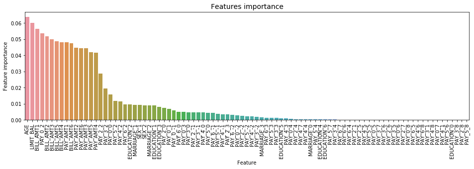

```python
tmp = pd.DataFrame({'Feature': predictors_f, 'Feature importance': clf.feature_importances_})
tmp = tmp.sort_values(by='Feature importance',ascending=False)
plt.figure(figsize = (16,4))
plt.title('Features importance',fontsize=14)
s = sns.barplot(x='Feature',y='Feature importance',data=tmp)
s.set_xticklabels(s.get_xticklabels(),rotation=90)
plt.show()
```

This time the most important features are AGE, LIMIT_BAL, BILL_AMT1, PAY_0_2, BILL_AMT2, BILL_AMT3.

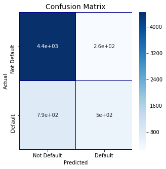

```python
cm = pd.crosstab(val_fa_df[target].values, preds, rownames=['Actual'], colnames=['Predicted'])
fig, (ax1) = plt.subplots(ncols=1, figsize=(5,5))
sns.heatmap(cm,
            xticklabels=['Not Default', 'Default'],
            yticklabels=['Not Default', 'Default'],
            annot=True,ax=ax1,
            linewidths=.2,linecolor="Darkblue", cmap="Blues")
plt.title('Confusion Matrix', fontsize=14)
plt.show()
```

```python
roc_auc_score(val_fa_df[target].values, preds)
```

```
0.6667660736878931
```

With the dummified features, the improvement of the AUC score is quite small.